# ETM 58D PROJECT

Ibrahim Aykut - Ata Batur Erdemir

29 06 2021

```r
library("dplyr")
library("lubridate")
```

```r
library("ggplot2")
library("glmnet")
library("tree")
library("randomForest")
library("skimr")
library("gapminder")
```

## Reading and Manipulating the Data

We read the data. We converted date column’s type to date. Also, we thought that timestamp column is not necessary. Therefore it was removed.

```r
y=read.csv("production_data_with_weather.csv")
y$Date=as.Date(y$Date)
y<-y[,-c(4)]
```

## DESCRIPTIVE ANALYSIS

To understand the data, we conducted some descriptive analysis. To see how production capacity changes as per hour, we ploted hour-production graph. We grouped each day’s average production value to plot time series graph.

```r
head(y)
```

```
##         Date Hour Production CLOUD_LOW_LAYER_37.75_34.25
## 1 2019-10-09    0          0                           0
## 2 2019-10-09    1          0                           0
## 3 2019-10-09    2          0                           0
## 4 2019-10-09    3          0                           0
## 5 2019-10-09    4          0                           0
## 6 2019-10-09    5          0                           0
##   CLOUD_LOW_LAYER_37.75_34.5 CLOUD_LOW_LAYER_38_34.25 CLOUD_LOW_LAYER_38_34.5
## 1                          0                        0                       0
## 2                          0                        0                       0
## 3                          0                        0                       0
## 4                          0                        0                       0
## 5                          0                        0                       0
## 6                          0                        0                       0
##   DSWRF_37.75_34.25 DSWRF_37.75_34.5 DSWRF_38_34.25 DSWRF_38_34.5
## 1                 0                0              0             0
## 2                 0                0              0             0
## 3                 0                0              0             0
## 4                 0                0              0             0
## 5                 0                0              0             0
## 6                 0                0              0             0
##   TEMP_37.75_34.25 TEMP_37.75_34.5 TEMP_38_34.25 TEMP_38_34.5
## 1           17.071          16.411        14.531       12.411
## 2           16.949          15.729        13.959       11.939
## 3           15.886          14.636        13.476       11.426
## 4           15.106          13.796        12.856       11.066
## 5           14.910          13.540        12.650       11.220
## 6           14.076          13.226        12.286       11.386
```

```r
summary(y)
```

```
##       Date                 Hour         Production
##  Min.   :2019-10-09   Min.   : 0.00   Min.   : 0.0
##  1st Qu.:2020-02-06   1st Qu.: 5.75   1st Qu.: 0.0
##  Median :2020-06-06   Median :11.50   Median : 0.0
##  Mean   :2020-06-06   Mean   :11.50   Mean   : 6.2
##  3rd Qu.:2020-10-05   3rd Qu.:17.25   3rd Qu.:11.8
##  Max.   :2021-02-02   Max.   :23.00   Max.   :30.0
##  CLOUD_LOW_LAYER_37.75_34.25 CLOUD_LOW_LAYER_37.75_34.5
##  Min.   :  0.00              Min.   :  0.00
##  1st Qu.:  0.00              1st Qu.:  0.00
##  Median :  0.00              Median :  0.00
##  Mean   : 14.74              Mean   : 15.45
##  3rd Qu.:  6.00              3rd Qu.: 10.00
##  Max.   :100.00              Max.   :100.00
##  CLOUD_LOW_LAYER_38_34.25 CLOUD_LOW_LAYER_38_34.5 DSWRF_37.75_34.25
##  Min.   :  0.00           Min.   :  0.00          Min.   :  0.0
##  1st Qu.:  0.00           1st Qu.:  0.00          1st Qu.:  0.0
##  Median :  0.00           Median :  0.00          Median : 70.0
##  Mean   : 16.17           Mean   : 16.33          Mean   :209.3
##  3rd Qu.: 11.00           3rd Qu.: 13.00          3rd Qu.:380.0
##  Max.   :100.00           Max.   :100.00          Max.   :950.0
##  DSWRF_37.75_34.5 DSWRF_38_34.25  DSWRF_38_34.5   TEMP_37.75_34.25
##  Min.   :  0.0    Min.   :  0.0   Min.   :  0.0   Min.   :-10.28
##  1st Qu.:  0.0    1st Qu.:  0.0   1st Qu.:  0.0   1st Qu.:  5.86
##  Median : 70.0    Median : 60.0   Median : 64.0   Median : 12.22
##  Mean   :208.6    Mean   :208.8   Mean   :207.9   Mean   : 12.97
##  3rd Qu.:380.0    3rd Qu.:380.0   3rd Qu.:372.8   3rd Qu.: 19.38
##  Max.   :950.0    Max.   :950.0   Max.   :952.0   Max.   : 38.95
##  TEMP_37.75_34.5   TEMP_38_34.25      TEMP_38_34.5
##  Min.   :-12.315   Min.   :-12.338   Min.   :-15.474
##  1st Qu.:  4.902   1st Qu.:  3.867   1st Qu.:  1.754
##  Median : 11.264   Median : 10.217   Median :  8.150
##  Mean   : 12.038   Mean   : 10.985   Mean   :  8.995
##  3rd Qu.: 18.412   3rd Qu.: 17.392   3rd Qu.: 15.550
##  Max.   : 37.650   Max.   : 36.250   Max.   : 33.650
```

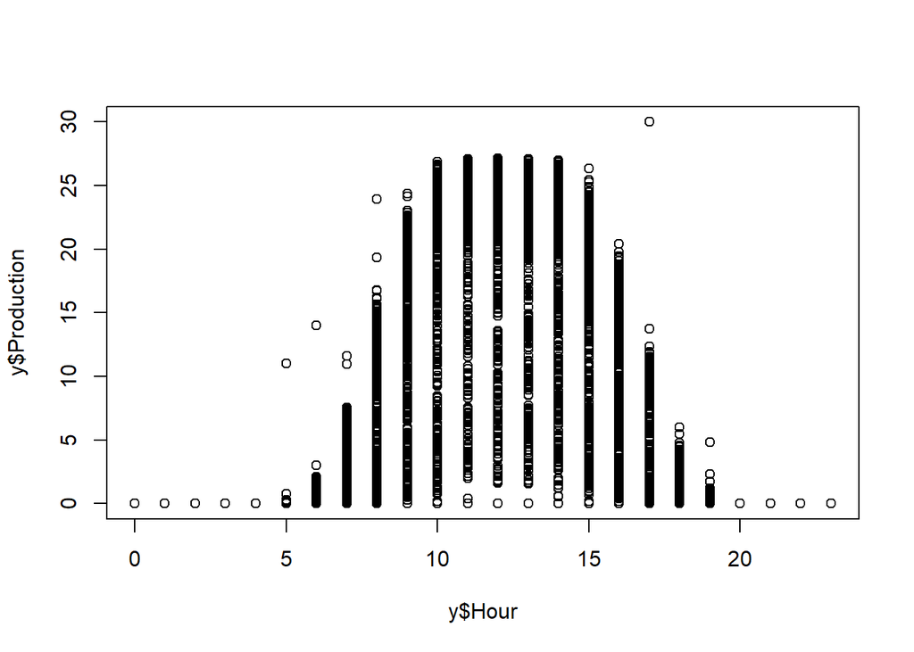

```r
plot(y$Hour,y$Production)
```

```r
sd(y$Production)
```

```
## [1] 9.038233
```

```r
skim(y)
```

Data summary

| Name | y |
| --- | --- |
| Number of rows | 11592 |
| Number of columns | 15 |
| _______________________ |  |
| Column type frequency: |  |
| Date | 1 |
| numeric | 14 |
| ________________________ |  |
| Group variables | None |

**Variable type: Date**

| skim_variable | n_missing | complete_rate | min | max | median | n_unique |
| --- | --- | --- | --- | --- | --- | --- |
| Date | 0 | 1 | 2019-10-09 | 2021-02-02 | 2020-06-06 | 483 |

**Variable type: numeric**

| skim_variable | n_missing | complete_rate | mean | sd | p0 | p25 | p50 | p75 | p100 | hist |
| --- | --- | --- | --- | --- | --- | --- | --- | --- | --- | --- |
| Hour | 0 | 1 | 11.50 | 6.92 | 0.00 | 5.75 | 11.50 | 17.25 | 23.00 | ▇▇▆▇▇ |
| Production | 0 | 1 | 6.20 | 9.04 | 0.00 | 0.00 | 0.00 | 11.80 | 30.00 | ▇▁▁▁▁ |
| CLOUD_LOW_LAYER_37.75_34.25 | 0 | 1 | 14.74 | 30.05 | 0.00 | 0.00 | 0.00 | 6.00 | 100.00 | ▇▁▁▁▁ |
| CLOUD_LOW_LAYER_37.75_34.5 | 0 | 1 | 15.45 | 30.36 | 0.00 | 0.00 | 0.00 | 10.00 | 100.00 | ▇▁▁▁▁ |
| CLOUD_LOW_LAYER_38_34.25 | 0 | 1 | 16.17 | 31.48 | 0.00 | 0.00 | 0.00 | 11.00 | 100.00 | ▇▁▁▁▁ |
| CLOUD_LOW_LAYER_38_34.5 | 0 | 1 | 16.33 | 31.30 | 0.00 | 0.00 | 0.00 | 13.00 | 100.00 | ▇▁▁▁▁ |
| DSWRF_37.75_34.25 | 0 | 1 | 209.32 | 268.02 | 0.00 | 0.00 | 70.00 | 380.00 | 950.00 | ▇▂▂▁▁ |
| DSWRF_37.75_34.5 | 0 | 1 | 208.64 | 267.75 | 0.00 | 0.00 | 70.00 | 380.00 | 950.00 | ▇▂▂▁▁ |
| DSWRF_38_34.25 | 0 | 1 | 208.81 | 268.09 | 0.00 | 0.00 | 60.00 | 380.00 | 950.00 | ▇▂▂▁▁ |
| DSWRF_38_34.5 | 0 | 1 | 207.94 | 267.06 | 0.00 | 0.00 | 64.00 | 372.75 | 952.00 | ▇▂▂▁▁ |
| TEMP_37.75_34.25 | 0 | 1 | 12.97 | 9.11 | -10.28 | 5.86 | 12.22 | 19.38 | 38.95 | ▁▇▇▅▁ |
| TEMP_37.75_34.5 | 0 | 1 | 12.04 | 9.15 | -12.31 | 4.90 | 11.26 | 18.41 | 37.65 | ▁▇▇▅▂ |
| TEMP_38_34.25 | 0 | 1 | 10.98 | 9.06 | -12.34 | 3.87 | 10.22 | 17.39 | 36.25 | ▁▇▇▅▂ |
| TEMP_38_34.5 | 0 | 1 | 8.99 | 9.05 | -15.47 | 1.75 | 8.15 | 15.55 | 33.65 | ▁▇▇▅▂ |

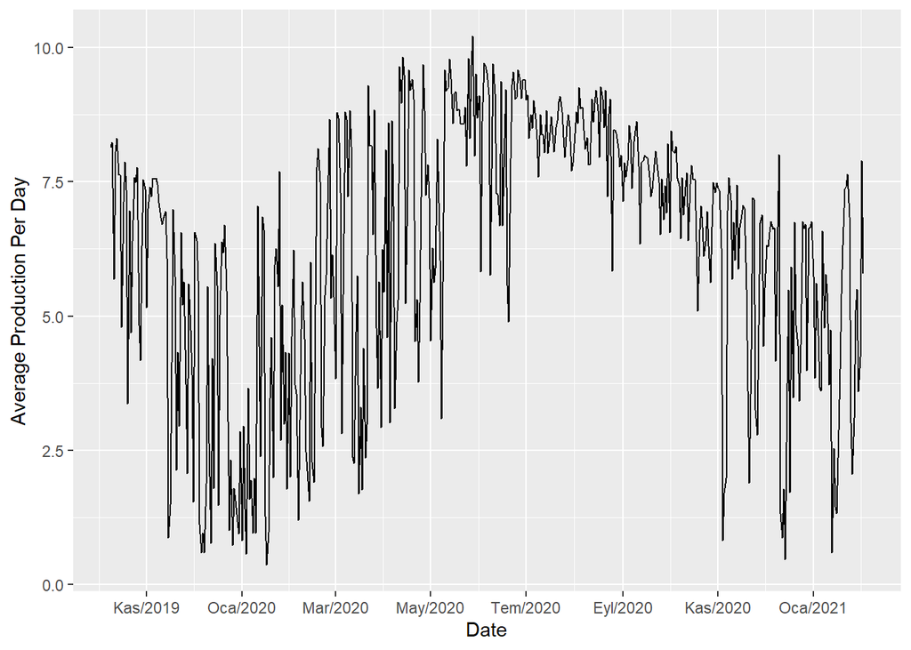

```r
plot_data=y %>% group_by(Date) %>% summarise(avg_production=mean(Production))
ggplot(plot_data,aes(x=Date,y=avg_production)) + scale_x_date(date_breaks = "2 month", date_labels = "%b/%Y") + geom_line() +
  labs(x="Date",y="Average Production Per Day")
```

## TRAINING DATA SET

We prefer to predict each hour’s production value seperately. Therefore, we divided the data to each hour and created the training data.

```r
trainingdata0=filter(y,Date>=as_date('2019-10-09'),Date<as_date('2020-12-01'),Hour==0)
trainingdata1=filter(y,Date>=as_date('2019-10-09'),Date<as_date('2020-12-01'),Hour==1)
trainingdata2=filter(y,Date>=as_date('2019-10-09'),Date<as_date('2020-12-01'),Hour==2)
trainingdata3=filter(y,Date>=as_date('2019-10-09'),Date<as_date('2020-12-01'),Hour==3)
trainingdata4=filter(y,Date>=as_date('2019-10-09'),Date<as_date('2020-12-01'),Hour==4)
trainingdata5=filter(y,Date>=as_date('2019-10-09'),Date<as_date('2020-12-01'),Hour==5)
trainingdata6=filter(y,Date>=as_date('2019-10-09'),Date<as_date('2020-12-01'),Hour==6)
trainingdata7=filter(y,Date>=as_date('2019-10-09'),Date<as_date('2020-12-01'),Hour==7)
trainingdata8=filter(y,Date>=as_date('2019-10-09'),Date<as_date('2020-12-01'),Hour==8)
trainingdata9=filter(y,Date>=as_date('2019-10-09'),Date<as_date('2020-12-01'),Hour==9)
trainingdata10=filter(y,Date>=as_date('2019-10-09'),Date<as_date('2020-12-01'),Hour==10)
trainingdata11=filter(y,Date>=as_date('2019-10-09'),Date<as_date('2020-12-01'),Hour==11)
trainingdata12=filter(y,Date>=as_date('2019-10-09'),Date<as_date('2020-12-01'),Hour==12)
trainingdata13=filter(y,Date>=as_date('2019-10-09'),Date<as_date('2020-12-01'),Hour==13)
trainingdata14=filter(y,Date>=as_date('2019-10-09'),Date<as_date('2020-12-01'),Hour==14)
trainingdata15=filter(y,Date>=as_date('2019-10-09'),Date<as_date('2020-12-01'),Hour==15)
trainingdata16=filter(y,Date>=as_date('2019-10-09'),Date<as_date('2020-12-01'),Hour==16)
trainingdata17=filter(y,Date>=as_date('2019-10-09'),Date<as_date('2020-12-01'),Hour==17)
trainingdata18=filter(y,Date>=as_date('2019-10-09'),Date<as_date('2020-12-01'),Hour==18)
trainingdata19=filter(y,Date>=as_date('2019-10-09'),Date<as_date('2020-12-01'),Hour==19)
trainingdata20=filter(y,Date>=as_date('2019-10-09'),Date<as_date('2020-12-01'),Hour==20)
trainingdata21=filter(y,Date>=as_date('2019-10-09'),Date<as_date('2020-12-01'),Hour==21)
trainingdata22=filter(y,Date>=as_date('2019-10-09'),Date<as_date('2020-12-01'),Hour==22)
trainingdata23=filter(y,Date>=as_date('2019-10-09'),Date<as_date('2020-12-01'),Hour==23)
```

## TEST DATA SET

We created the test data for each hour.

```r
testdata0=filter(y,Date>=as_date('2020-12-01'),Date<as_date('2021-01-31'),Hour==0)
testdata1=filter(y,Date>=as_date('2020-12-01'),Date<as_date('2021-01-31'),Hour==1)
testdata2=filter(y,Date>=as_date('2020-12-01'),Date<as_date('2021-01-31'),Hour==2)
testdata3=filter(y,Date>=as_date('2020-12-01'),Date<as_date('2021-01-31'),Hour==3)
testdata4=filter(y,Date>=as_date('2020-12-01'),Date<as_date('2021-01-31'),Hour==4)
testdata5=filter(y,Date>=as_date('2020-12-01'),Date<as_date('2021-01-31'),Hour==5)
testdata6=filter(y,Date>=as_date('2020-12-01'),Date<as_date('2021-01-31'),Hour==6)
testdata7=filter(y,Date>=as_date('2020-12-01'),Date<as_date('2021-01-31'),Hour==7)
testdata8=filter(y,Date>=as_date('2020-12-01'),Date<as_date('2021-01-31'),Hour==8)
testdata9=filter(y,Date>=as_date('2020-12-01'),Date<as_date('2021-01-31'),Hour==9)
testdata10=filter(y,Date>=as_date('2020-12-01'),Date<as_date('2021-01-31'),Hour==10)
testdata11=filter(y,Date>=as_date('2020-12-01'),Date<as_date('2021-01-31'),Hour==11)
testdata12=filter(y,Date>=as_date('2020-12-01'),Date<as_date('2021-01-31'),Hour==12)
testdata13=filter(y,Date>=as_date('2020-12-01'),Date<as_date('2021-01-31'),Hour==13)
testdata14=filter(y,Date>=as_date('2020-12-01'),Date<as_date('2021-01-31'),Hour==14)
testdata15=filter(y,Date>=as_date('2020-12-01'),Date<as_date('2021-01-31'),Hour==15)
testdata16=filter(y,Date>=as_date('2020-12-01'),Date<as_date('2021-01-31'),Hour==16)
testdata17=filter(y,Date>=as_date('2020-12-01'),Date<as_date('2021-01-31'),Hour==17)
testdata18=filter(y,Date>=as_date('2020-12-01'),Date<as_date('2021-01-31'),Hour==18)
testdata19=filter(y,Date>=as_date('2020-12-01'),Date<as_date('2021-01-31'),Hour==19)
testdata20=filter(y,Date>=as_date('2020-12-01'),Date<as_date('2021-01-31'),Hour==20)
testdata21=filter(y,Date>=as_date('2020-12-01'),Date<as_date('2021-01-31'),Hour==21)
testdata22=filter(y,Date>=as_date('2020-12-01'),Date<as_date('2021-01-31'),Hour==22)
testdata23=filter(y,Date>=as_date('2020-12-01'),Date<as_date('2021-01-31'),Hour==23)
```

# MODEL SELECTION

In this work, we decided to use linear regression, random forest, lasso regression and tree model. When we examined the dataset, it is seem that there is not any production from 20 pm to 5 am for all days. Therefore, we decided to train and predict observations from 5 am to 20 pm.

## LINEAR REGRESSION

```r
linear_model5=lm(Production~.-Date-Hour,data=trainingdata5)
summary(linear_model5)
```

```
##
## Call:
## lm(formula = Production ~ . - Date - Hour, data = trainingdata5)
##
## Residuals:
##     Min      1Q  Median      3Q     Max
## -0.1599 -0.0688 -0.0297  0.0116 10.8698
##
## Coefficients: (4 not defined because of singularities)
##                               Estimate Std. Error t value Pr(>|t|)
## (Intercept)                 -1.283e-01  1.016e-01  -1.262    0.207
## CLOUD_LOW_LAYER_37.75_34.25 -9.072e-04  2.985e-03  -0.304    0.761
## CLOUD_LOW_LAYER_37.75_34.5   8.401e-04  3.121e-03   0.269    0.788
## CLOUD_LOW_LAYER_38_34.25     2.435e-04  2.185e-03   0.111    0.911
## CLOUD_LOW_LAYER_38_34.5     -1.417e-05  2.298e-03  -0.006    0.995
## DSWRF_37.75_34.25                   NA         NA      NA       NA
## DSWRF_37.75_34.5                    NA         NA      NA       NA
## DSWRF_38_34.25                      NA         NA      NA       NA
## DSWRF_38_34.5                       NA         NA      NA       NA
## TEMP_37.75_34.25             6.920e-02  5.131e-02   1.349    0.178
## TEMP_37.75_34.5             -3.437e-02  4.812e-02  -0.714    0.475
## TEMP_38_34.25               -1.987e-02  4.260e-02  -0.466    0.641
## TEMP_38_34.5                -7.960e-03  3.016e-02  -0.264    0.792
##
## Residual standard error: 0.5415 on 410 degrees of freedom
## Multiple R-squared:  0.0121, Adjusted R-squared:  -0.007181
## F-statistic: 0.6275 on 8 and 410 DF,  p-value: 0.7548
```

```r
linear_model5_MSE=mean((trainingdata5$Production-linear_model5$fitted.values)^2)
linear_model5_predicted=predict(linear_model5,testdata5)
linear_model5_MSE_test=mean((testdata5$Production-linear_model5_predicted)^2)

linear_model6=lm(Production~.-Date-Hour,data=trainingdata6)
summary(linear_model6)
```

```
##
## Call:
## lm(formula = Production ~ . - Date - Hour, data = trainingdata6)
##
## Residuals:
##     Min      1Q  Median      3Q     Max
## -1.0157 -0.2914 -0.0982  0.1079 13.3947
##
## Coefficients:
##                               Estimate Std. Error t value Pr(>|t|)
## (Intercept)                 -2.604e-01  1.573e-01  -1.656   0.0985 .
## CLOUD_LOW_LAYER_37.75_34.25 -2.374e-03  5.063e-03  -0.469   0.6394
## CLOUD_LOW_LAYER_37.75_34.5   1.141e-04  4.992e-03   0.023   0.9818
## CLOUD_LOW_LAYER_38_34.25     2.036e-03  3.657e-03   0.557   0.5779
## CLOUD_LOW_LAYER_38_34.5     -9.065e-05  3.953e-03  -0.023   0.9817
## DSWRF_37.75_34.25            4.625e-02  5.226e-02   0.885   0.3766
## DSWRF_37.75_34.5             5.068e-02  8.440e-02   0.601   0.5485
## DSWRF_38_34.25               5.565e-03  8.601e-02   0.065   0.9484
## DSWRF_38_34.5                5.176e-02  3.573e-02   1.448   0.1483
## TEMP_37.75_34.25             1.092e-01  8.171e-02   1.336   0.1822
## TEMP_37.75_34.5              7.324e-02  7.260e-02   1.009   0.3137
## TEMP_38_34.25               -1.147e-01  6.139e-02  -1.869   0.0623 .
## TEMP_38_34.5                -3.241e-02  4.353e-02  -0.745   0.4570
## ---
## Signif. codes:  0 '***' 0.001 '**' 0.01 '*' 0.05 '.' 0.1 ' ' 1
##
## Residual standard error: 0.7857 on 406 degrees of freedom
## Multiple R-squared:  0.2269, Adjusted R-squared:  0.2041
## F-statistic: 9.932 on 12 and 406 DF,  p-value: < 2.2e-16
```

```r
linear_model6_MSE=mean((trainingdata6$Production-linear_model6$fitted.values)^2)
linear_model6_predicted=predict(linear_model6,testdata6)
linear_model6_MSE_test=mean((testdata6$Production-linear_model6_predicted)^2)

linear_model7=lm(Production~.-Date-Hour,data=trainingdata7)
summary(linear_model7)
```

```
##
## Call:
## lm(formula = Production ~ . - Date - Hour, data = trainingdata7)
##
## Residuals:
##     Min      1Q  Median      3Q     Max
## -6.5634 -0.7470 -0.2038  0.6035  9.2859
##
## Coefficients:
##                              Estimate Std. Error t value Pr(>|t|)
## (Intercept)                  0.818682   0.256078   3.197 0.001497 **
## CLOUD_LOW_LAYER_37.75_34.25 -0.003983   0.009175  -0.434 0.664406
## CLOUD_LOW_LAYER_37.75_34.5   0.003975   0.008720   0.456 0.648704
## CLOUD_LOW_LAYER_38_34.25    -0.005643   0.006808  -0.829 0.407704
## CLOUD_LOW_LAYER_38_34.5     -0.004073   0.007037  -0.579 0.563050
## DSWRF_37.75_34.25            0.172324   0.049996   3.447 0.000627 ***
## DSWRF_37.75_34.5            -0.056584   0.064036  -0.884 0.377420
## DSWRF_38_34.25              -0.112043   0.055539  -2.017 0.044315 *
## DSWRF_38_34.5                0.097869   0.042912   2.281 0.023084 *
## TEMP_37.75_34.25             0.081482   0.135545   0.601 0.548080
## TEMP_37.75_34.5             -0.043464   0.123486  -0.352 0.725037
## TEMP_38_34.25                0.067073   0.113182   0.593 0.553772
## TEMP_38_34.5                 0.018417   0.079003   0.233 0.815787
## ---
## Signif. codes:  0 '***' 0.001 '**' 0.01 '*' 0.05 '.' 0.1 ' ' 1
##
## Residual standard error: 1.297 on 406 degrees of freedom
## Multiple R-squared:  0.7552, Adjusted R-squared:  0.748
## F-statistic: 104.4 on 12 and 406 DF,  p-value: < 2.2e-16
```

```r
linear_model7_MSE=mean((trainingdata7$Production-linear_model7$fitted.values)^2)
linear_model7_predicted=predict(linear_model7,testdata7)
linear_model7_MSE_test=mean((testdata7$Production-linear_model7_predicted)^2)

linear_model8=lm(Production~.-Date-Hour,data=trainingdata8)
summary(linear_model8)
```

```
##
## Call:
## lm(formula = Production ~ . - Date - Hour, data = trainingdata8)
##
## Residuals:
##      Min       1Q   Median       3Q      Max
## -13.8245  -1.5014   0.0924   1.5382  10.2812
##
## Coefficients:
##                              Estimate Std. Error t value Pr(>|t|)
## (Intercept)                  4.353346   0.499554   8.714  < 2e-16 ***
## CLOUD_LOW_LAYER_37.75_34.25 -0.002438   0.019291  -0.126 0.899503
## CLOUD_LOW_LAYER_37.75_34.5  -0.013024   0.018712  -0.696 0.486832
## CLOUD_LOW_LAYER_38_34.25    -0.050404   0.014820  -3.401 0.000738 ***
## CLOUD_LOW_LAYER_38_34.5      0.016756   0.015569   1.076 0.282461
## DSWRF_37.75_34.25            0.093949   0.047314   1.986 0.047747 *
## DSWRF_37.75_34.5            -0.060385   0.058216  -1.037 0.300229
## DSWRF_38_34.25              -0.078038   0.063089  -1.237 0.216820
## DSWRF_38_34.5                0.108910   0.059954   1.817 0.070023 .
## TEMP_37.75_34.25             0.016236   0.316866   0.051 0.959160
## TEMP_37.75_34.5              0.206865   0.324561   0.637 0.524245
## TEMP_38_34.25                0.179223   0.270953   0.661 0.508696
## TEMP_38_34.5                -0.214219   0.179872  -1.191 0.234368
## ---
## Signif. codes:  0 '***' 0.001 '**' 0.01 '*' 0.05 '.' 0.1 ' ' 1
##
## Residual standard error: 2.591 on 406 degrees of freedom
## Multiple R-squared:  0.758,  Adjusted R-squared:  0.7508
## F-statistic: 105.9 on 12 and 406 DF,  p-value: < 2.2e-16
```

```r
linear_model8_MSE=mean((trainingdata8$Production-linear_model8$fitted.values)^2)
linear_model8_predicted=predict(linear_model8,testdata8)
linear_model8_MSE_test=mean((testdata8$Production-linear_model8_predicted)^2)

linear_model9=lm(Production~.-Date-Hour,data=trainingdata9)
summary(linear_model9)
```

```
##
## Call:
## lm(formula = Production ~ . - Date - Hour, data = trainingdata9)
##
## Residuals:
##      Min       1Q   Median       3Q      Max
## -16.0851  -1.7628   0.3495   2.5182  11.4410
##
## Coefficients:
##                             Estimate Std. Error t value Pr(>|t|)
## (Intercept)                 11.60403    0.68075  17.046  < 2e-16 ***
## CLOUD_LOW_LAYER_37.75_34.25 -0.01036    0.03077  -0.337 0.736662
## CLOUD_LOW_LAYER_37.75_34.5  -0.02637    0.03070  -0.859 0.391000
## CLOUD_LOW_LAYER_38_34.25    -0.10515    0.02310  -4.551 7.07e-06 ***
## CLOUD_LOW_LAYER_38_34.5      0.04149    0.02444   1.698 0.090301 .
## DSWRF_37.75_34.25            0.09117    0.04037   2.258 0.024475 *
## DSWRF_37.75_34.5            -0.01613    0.05589  -0.289 0.773092
## DSWRF_38_34.25              -0.04939    0.04922  -1.003 0.316237
## DSWRF_38_34.5                0.02501    0.05115   0.489 0.625196
## TEMP_37.75_34.25            -1.64234    0.48060  -3.417 0.000696 ***
## TEMP_37.75_34.5              1.44114    0.46893   3.073 0.002260 **
## TEMP_38_34.25                0.63980    0.48267   1.326 0.185737
## TEMP_38_34.5                -0.37079    0.30722  -1.207 0.228171
## ---
## Signif. codes:  0 '***' 0.001 '**' 0.01 '*' 0.05 '.' 0.1 ' ' 1
##
## Residual standard error: 3.772 on 406 degrees of freedom
## Multiple R-squared:  0.6951, Adjusted R-squared:  0.6861
## F-statistic: 77.13 on 12 and 406 DF,  p-value: < 2.2e-16
```

```r
linear_model9_MSE=mean((trainingdata9$Production-linear_model9$fitted.values)^2)
linear_model9_predicted=predict(linear_model9,testdata9)
linear_model9_MSE_test=mean((testdata9$Production-linear_model9_predicted)^2)

linear_model10=lm(Production~.-Date-Hour,data=trainingdata10)
summary(linear_model10)
```

```
##
## Call:
## lm(formula = Production ~ . - Date - Hour, data = trainingdata10)
##
## Residuals:
##      Min       1Q   Median       3Q      Max
## -18.3579  -2.0108   0.3521   3.3787  12.5403
##
## Coefficients:
##                              Estimate Std. Error t value Pr(>|t|)
## (Intercept)                 12.271301   0.871508  14.081  < 2e-16 ***
## CLOUD_LOW_LAYER_37.75_34.25  0.018464   0.032364   0.571 0.568638
## CLOUD_LOW_LAYER_37.75_34.5  -0.033352   0.029845  -1.118 0.264440
## CLOUD_LOW_LAYER_38_34.25    -0.048793   0.019068  -2.559 0.010864 *
## CLOUD_LOW_LAYER_38_34.5     -0.035415   0.017644  -2.007 0.045384 *
## DSWRF_37.75_34.25            0.022460   0.010977   2.046 0.041390 *
## DSWRF_37.75_34.5             0.002085   0.009722   0.214 0.830274
## DSWRF_38_34.25              -0.004580   0.009271  -0.494 0.621600
## DSWRF_38_34.5               -0.002998   0.009502  -0.316 0.752505
## TEMP_37.75_34.25            -1.732160   0.550726  -3.145 0.001782 **
## TEMP_37.75_34.5              2.055901   0.526138   3.908 0.000109 ***
## TEMP_38_34.25                0.094443   0.652778   0.145 0.885037
## TEMP_38_34.5                -0.407996   0.397269  -1.027 0.305031
## ---
## Signif. codes:  0 '***' 0.001 '**' 0.01 '*' 0.05 '.' 0.1 ' ' 1
##
## Residual standard error: 4.673 on 406 degrees of freedom
## Multiple R-squared:  0.6116, Adjusted R-squared:  0.6001
## F-statistic: 53.27 on 12 and 406 DF,  p-value: < 2.2e-16
```

```r
linear_model10_MSE=mean((trainingdata10$Production-linear_model10$fitted.values)^2)
linear_model10_predicted=predict(linear_model10,testdata10)
linear_model10_MSE_test=mean((testdata10$Production-linear_model10_predicted)^2)

linear_model11=lm(Production~.-Date-Hour,data=trainingdata11)
summary(linear_model11)
```

```
##
## Call:
## lm(formula = Production ~ . - Date - Hour, data = trainingdata11)
##
## Residuals:
##      Min       1Q   Median       3Q      Max
## -24.7856  -1.5605   0.7452   3.0352  18.2524
##
## Coefficients:
##                              Estimate Std. Error t value Pr(>|t|)
## (Intercept)                 16.000697   1.031289  15.515  < 2e-16 ***
## CLOUD_LOW_LAYER_37.75_34.25 -0.084798   0.038351  -2.211 0.027583 *
## CLOUD_LOW_LAYER_37.75_34.5   0.067160   0.035715   1.880 0.060762 .
## CLOUD_LOW_LAYER_38_34.25    -0.063952   0.023719  -2.696 0.007304 **
## CLOUD_LOW_LAYER_38_34.5     -0.038718   0.023058  -1.679 0.093895 .
## DSWRF_37.75_34.25            0.006818   0.011940   0.571 0.568299
## DSWRF_37.75_34.5             0.017849   0.010019   1.782 0.075577 .
## DSWRF_38_34.25               0.003766   0.010277   0.366 0.714214
## DSWRF_38_34.5               -0.015743   0.010020  -1.571 0.116935
## TEMP_37.75_34.25            -1.801548   0.519036  -3.471 0.000574 ***
## TEMP_37.75_34.5              1.781161   0.481168   3.702 0.000244 ***
## TEMP_38_34.25                0.488234   0.641548   0.761 0.447084
## TEMP_38_34.5                -0.487435   0.414075  -1.177 0.239819
## ---
## Signif. codes:  0 '***' 0.001 '**' 0.01 '*' 0.05 '.' 0.1 ' ' 1
##
## Residual standard error: 5.089 on 406 degrees of freedom
## Multiple R-squared:  0.5382, Adjusted R-squared:  0.5245
## F-statistic: 39.43 on 12 and 406 DF,  p-value: < 2.2e-16
```

```r
linear_model11_MSE=mean((trainingdata11$Production-linear_model11$fitted.values)^2)
linear_model11_predicted=predict(linear_model11,testdata11)
linear_model11_MSE_test=mean((testdata11$Production-linear_model11_predicted)^2)

linear_model12=lm(Production~.-Date-Hour,data=trainingdata12)
summary(linear_model12)
```

```
##
## Call:
## lm(formula = Production ~ . - Date - Hour, data = trainingdata12)
##
## Residuals:
##      Min       1Q   Median       3Q      Max
## -24.3348  -1.6954   0.8122   2.8377  13.0086
##
## Coefficients:
##                              Estimate Std. Error t value Pr(>|t|)
## (Intercept)                 15.547451   1.116959  13.919  < 2e-16 ***
## CLOUD_LOW_LAYER_37.75_34.25 -0.036375   0.042558  -0.855  0.39321
## CLOUD_LOW_LAYER_37.75_34.5  -0.003240   0.040150  -0.081  0.93572
## CLOUD_LOW_LAYER_38_34.25    -0.078961   0.024823  -3.181  0.00158 **
## CLOUD_LOW_LAYER_38_34.5      0.001256   0.024703   0.051  0.95947
## DSWRF_37.75_34.25            0.020021   0.011794   1.698  0.09036 .
## DSWRF_37.75_34.5             0.002233   0.009635   0.232  0.81682
## DSWRF_38_34.25              -0.014662   0.011048  -1.327  0.18520
## DSWRF_38_34.5                0.006854   0.009568   0.716  0.47421
## TEMP_37.75_34.25            -2.025587   0.476148  -4.254 2.61e-05 ***
## TEMP_37.75_34.5              1.839157   0.446405   4.120 4.60e-05 ***
## TEMP_38_34.25                0.560252   0.630812   0.888  0.37499
## TEMP_38_34.5                -0.454024   0.411847  -1.102  0.27094
## ---
## Signif. codes:  0 '***' 0.001 '**' 0.01 '*' 0.05 '.' 0.1 ' ' 1
##
## Residual standard error: 4.963 on 406 degrees of freedom
## Multiple R-squared:  0.5524, Adjusted R-squared:  0.5391
## F-statistic: 41.75 on 12 and 406 DF,  p-value: < 2.2e-16
```

```r
linear_model12_MSE=mean((trainingdata12$Production-linear_model12$fitted.values)^2)
linear_model12_predicted=predict(linear_model12,testdata12)
linear_model12_MSE_test=mean((testdata12$Production-linear_model12_predicted)^2)

linear_model13=lm(Production~.-Date-Hour,data=trainingdata13)
summary(linear_model13)
```

```
##
## Call:
## lm(formula = Production ~ . - Date - Hour, data = trainingdata13)
##
## Residuals:
##      Min       1Q   Median       3Q      Max
## -23.9995  -1.8456   0.7768   3.0596  15.4275
##
## Coefficients:
##                              Estimate Std. Error t value Pr(>|t|)
## (Intercept)                 14.497935   1.256548  11.538  < 2e-16 ***
## CLOUD_LOW_LAYER_37.75_34.25  0.010322   0.048914   0.211 0.832976
## CLOUD_LOW_LAYER_37.75_34.5  -0.052534   0.046526  -1.129 0.259506
## CLOUD_LOW_LAYER_38_34.25    -0.108043   0.028908  -3.737 0.000213 ***
## CLOUD_LOW_LAYER_38_34.5      0.038400   0.027253   1.409 0.159592
## DSWRF_37.75_34.25            0.010304   0.011639   0.885 0.376542
## DSWRF_37.75_34.5             0.004413   0.010176   0.434 0.664733
## DSWRF_38_34.25              -0.019265   0.010394  -1.854 0.064533 .
## DSWRF_38_34.5                0.017416   0.008959   1.944 0.052602 .
## TEMP_37.75_34.25            -2.425549   0.476364  -5.092 5.44e-07 ***
## TEMP_37.75_34.5              1.817737   0.460312   3.949 9.25e-05 ***
## TEMP_38_34.25                1.465989   0.624972   2.346 0.019472 *
## TEMP_38_34.5                -0.886143   0.427770  -2.072 0.038939 *
## ---
## Signif. codes:  0 '***' 0.001 '**' 0.01 '*' 0.05 '.' 0.1 ' ' 1
##
## Residual standard error: 5.149 on 406 degrees of freedom
## Multiple R-squared:  0.5476, Adjusted R-squared:  0.5342
## F-statistic: 40.95 on 12 and 406 DF,  p-value: < 2.2e-16
```

```r
linear_model13_MSE=mean((trainingdata13$Production-linear_model13$fitted.values)^2)
linear_model13_predicted=predict(linear_model13,testdata13)
linear_model13_MSE_test=mean((testdata13$Production-linear_model13_predicted)^2)

linear_model14=lm(Production~.-Date-Hour,data=trainingdata14)
summary(linear_model14)
```

```
##
## Call:
## lm(formula = Production ~ . - Date - Hour, data = trainingdata14)
##
## Residuals:
##      Min       1Q   Median       3Q      Max
## -23.0811  -2.1600   0.9395   3.6858  12.9775
##
## Coefficients:
##                              Estimate Std. Error t value Pr(>|t|)
## (Intercept)                 11.048350   1.381563   7.997 1.34e-14 ***
## CLOUD_LOW_LAYER_37.75_34.25 -0.010602   0.053447  -0.198  0.84285
## CLOUD_LOW_LAYER_37.75_34.5  -0.042607   0.050494  -0.844  0.39928
## CLOUD_LOW_LAYER_38_34.25    -0.066331   0.031671  -2.094  0.03685 *
## CLOUD_LOW_LAYER_38_34.5      0.035974   0.029409   1.223  0.22195
## DSWRF_37.75_34.25            0.024429   0.011668   2.094  0.03691 *
## DSWRF_37.75_34.5            -0.016074   0.010353  -1.553  0.12130
## DSWRF_38_34.25              -0.005035   0.010584  -0.476  0.63456
## DSWRF_38_34.5                0.011876   0.008978   1.323  0.18666
## TEMP_37.75_34.25            -1.599268   0.510537  -3.133  0.00186 **
## TEMP_37.75_34.5              1.125818   0.502404   2.241  0.02558 *
## TEMP_38_34.25                0.868916   0.661940   1.313  0.19003
## TEMP_38_34.5                -0.406299   0.474429  -0.856  0.39228
## ---
## Signif. codes:  0 '***' 0.001 '**' 0.01 '*' 0.05 '.' 0.1 ' ' 1
##
## Residual standard error: 5.414 on 406 degrees of freedom
## Multiple R-squared:  0.4855, Adjusted R-squared:  0.4703
## F-statistic: 31.92 on 12 and 406 DF,  p-value: < 2.2e-16
```

```r
linear_model14_MSE=mean((trainingdata14$Production-linear_model14$fitted.values)^2)
linear_model14_predicted=predict(linear_model14,testdata14)
linear_model14_MSE_test=mean((testdata14$Production-linear_model14_predicted)^2)

linear_model15=lm(Production~.-Date-Hour,data=trainingdata15)
summary(linear_model15)
```

```
##
## Call:
## lm(formula = Production ~ . - Date - Hour, data = trainingdata15)
##
## Residuals:
##      Min       1Q   Median       3Q      Max
## -17.7924  -1.8950   0.7277   2.7801  14.0851
##
## Coefficients:
##                              Estimate Std. Error t value Pr(>|t|)
## (Intercept)                  4.320782   1.227075   3.521 0.000478 ***
## CLOUD_LOW_LAYER_37.75_34.25 -0.050383   0.046994  -1.072 0.284304
## CLOUD_LOW_LAYER_37.75_34.5   0.074408   0.044539   1.671 0.095564 .
## CLOUD_LOW_LAYER_38_34.25    -0.126593   0.027591  -4.588 5.96e-06 ***
## CLOUD_LOW_LAYER_38_34.5      0.055032   0.025961   2.120 0.034630 *
## DSWRF_37.75_34.25            0.017703   0.010253   1.727 0.085003 .
## DSWRF_37.75_34.5            -0.001487   0.009020  -0.165 0.869162
## DSWRF_38_34.25              -0.013240   0.009056  -1.462 0.144505
## DSWRF_38_34.5                0.017541   0.007407   2.368 0.018345 *
## TEMP_37.75_34.25            -1.414495   0.434484  -3.256 0.001227 **
## TEMP_37.75_34.5              1.369131   0.412739   3.317 0.000991 ***
## TEMP_38_34.25                0.271020   0.545956   0.496 0.619871
## TEMP_38_34.5                -0.259465   0.408593  -0.635 0.525773
## ---
## Signif. codes:  0 '***' 0.001 '**' 0.01 '*' 0.05 '.' 0.1 ' ' 1
##
## Residual standard error: 4.637 on 406 degrees of freedom
## Multiple R-squared:  0.5729, Adjusted R-squared:  0.5603
## F-statistic: 45.39 on 12 and 406 DF,  p-value: < 2.2e-16
```

```r
linear_model15_MSE=mean((trainingdata15$Production-linear_model15$fitted.values)^2)
linear_model15_predicted=predict(linear_model15,testdata15)
linear_model15_MSE_test=mean((testdata15$Production-linear_model15_predicted)^2)

linear_model16=lm(Production~.-Date-Hour,data=trainingdata16)
summary(linear_model16)
```

```
##
## Call:
## lm(formula = Production ~ . - Date - Hour, data = trainingdata16)
##
## Residuals:
##     Min      1Q  Median      3Q     Max
## -12.401  -1.659   0.386   1.977  11.874
##
## Coefficients:
##                              Estimate Std. Error t value Pr(>|t|)
## (Intercept)                  0.270697   0.882790   0.307  0.75928
## CLOUD_LOW_LAYER_37.75_34.25 -0.043865   0.014846  -2.955  0.00331 **
## CLOUD_LOW_LAYER_37.75_34.5   0.036595   0.015519   2.358  0.01885 *
## CLOUD_LOW_LAYER_38_34.25    -0.017069   0.009940  -1.717  0.08669 .
## CLOUD_LOW_LAYER_38_34.5      0.019453   0.011250   1.729  0.08455 .
## DSWRF_37.75_34.25            0.010499   0.004083   2.572  0.01048 *
## DSWRF_37.75_34.5             0.004064   0.003717   1.093  0.27487
## DSWRF_38_34.25              -0.000392   0.003427  -0.114  0.90901
## DSWRF_38_34.5                0.006343   0.002710   2.341  0.01974 *
## TEMP_37.75_34.25            -0.858294   0.321068  -2.673  0.00782 **
## TEMP_37.75_34.5              0.538685   0.329869   1.633  0.10324
## TEMP_38_34.25                0.599982   0.371746   1.614  0.10731
## TEMP_38_34.5                -0.249189   0.299543  -0.832  0.40596
## ---
## Signif. codes:  0 '***' 0.001 '**' 0.01 '*' 0.05 '.' 0.1 ' ' 1
##
## Residual standard error: 3.309 on 406 degrees of freedom
## Multiple R-squared:  0.6917, Adjusted R-squared:  0.6826
## F-statistic: 75.91 on 12 and 406 DF,  p-value: < 2.2e-16
```

```r
linear_model16_MSE=mean((trainingdata16$Production-linear_model16$fitted.values)^2)
linear_model16_predicted=predict(linear_model16,testdata16)
linear_model16_MSE_test=mean((testdata16$Production-linear_model16_predicted)^2)

linear_model17=lm(Production~.-Date-Hour,data=trainingdata17)
summary(linear_model17)
```

```
##
## Call:
## lm(formula = Production ~ . - Date - Hour, data = trainingdata17)
##
## Residuals:
##     Min      1Q  Median      3Q     Max
## -9.3812 -0.6369  0.1880  0.9883  7.4299
##
## Coefficients:
##                              Estimate Std. Error t value Pr(>|t|)
## (Intercept)                 -3.754869   0.560363  -6.701 6.94e-11 ***
## CLOUD_LOW_LAYER_37.75_34.25 -0.007427   0.010196  -0.728   0.4667
## CLOUD_LOW_LAYER_37.75_34.5   0.014929   0.010128   1.474   0.1413
## CLOUD_LOW_LAYER_38_34.25     0.012217   0.007093   1.722   0.0858 .
## CLOUD_LOW_LAYER_38_34.5     -0.004761   0.007117  -0.669   0.5039
## DSWRF_37.75_34.25            0.007800   0.003360   2.321   0.0208 *
## DSWRF_37.75_34.5             0.001123   0.003217   0.349   0.7273
## DSWRF_38_34.25               0.005891   0.002594   2.271   0.0237 *
## DSWRF_38_34.5                0.003024   0.002138   1.414   0.1580
## TEMP_37.75_34.25            -0.281453   0.207062  -1.359   0.1748
## TEMP_37.75_34.5              0.445282   0.186609   2.386   0.0175 *
## TEMP_38_34.25                0.130465   0.243680   0.535   0.5927
## TEMP_38_34.5                -0.287551   0.174078  -1.652   0.0993 .
## ---
## Signif. codes:  0 '***' 0.001 '**' 0.01 '*' 0.05 '.' 0.1 ' ' 1
##
## Residual standard error: 2.003 on 406 degrees of freedom
## Multiple R-squared:  0.7695, Adjusted R-squared:  0.7627
## F-statistic: 112.9 on 12 and 406 DF,  p-value: < 2.2e-16
```

```r
linear_model17_MSE=mean((trainingdata17$Production-linear_model17$fitted.values)^2)
linear_model17_predicted=predict(linear_model17,testdata17)
linear_model17_MSE_test=mean((testdata17$Production-linear_model17_predicted)^2)

linear_model18=lm(Production~.-Date-Hour,data=trainingdata18)
summary(linear_model18)
```

```
##
## Call:
## lm(formula = Production ~ . - Date - Hour, data = trainingdata18)
##
## Residuals:
##     Min      1Q  Median      3Q     Max
## -3.1808 -0.3945  0.0814  0.4729  2.9894
##
## Coefficients:
##                               Estimate Std. Error t value Pr(>|t|)
## (Intercept)                 -1.049e+00  2.174e-01  -4.825 1.98e-06 ***
## CLOUD_LOW_LAYER_37.75_34.25  1.697e-03  4.261e-03   0.398  0.69063
## CLOUD_LOW_LAYER_37.75_34.5  -3.446e-03  4.546e-03  -0.758  0.44886
## CLOUD_LOW_LAYER_38_34.25     6.311e-03  2.892e-03   2.182  0.02966 *
## CLOUD_LOW_LAYER_38_34.5      8.197e-05  2.965e-03   0.028  0.97796
## DSWRF_37.75_34.25           -2.219e-04  1.582e-03  -0.140  0.88848
## DSWRF_37.75_34.5             1.846e-03  1.552e-03   1.190  0.23485
## DSWRF_38_34.25               5.440e-03  1.264e-03   4.302 2.12e-05 ***
## DSWRF_38_34.5               -2.945e-04  1.045e-03  -0.282  0.77817
## TEMP_37.75_34.25             2.107e-02  6.679e-02   0.315  0.75261
## TEMP_37.75_34.5              6.022e-02  6.505e-02   0.926  0.35516
## TEMP_38_34.25               -2.135e-01  7.531e-02  -2.835  0.00481 **
## TEMP_38_34.5                 1.346e-01  6.016e-02   2.238  0.02579 *
## ---
## Signif. codes:  0 '***' 0.001 '**' 0.01 '*' 0.05 '.' 0.1 ' ' 1
##
## Residual standard error: 0.77 on 406 degrees of freedom
## Multiple R-squared:  0.7341, Adjusted R-squared:  0.7262
## F-statistic:  93.4 on 12 and 406 DF,  p-value: < 2.2e-16
```

```r
linear_model18_MSE=mean((trainingdata18$Production-linear_model18$fitted.values)^2)
linear_model18_predicted=predict(linear_model18,testdata18)
linear_model18_MSE_test=mean((testdata18$Production-linear_model18_predicted)^2)

linear_model19=lm(Production~.-Date-Hour,data=trainingdata19)
summary(linear_model19)
```

```
##
## Call:
## lm(formula = Production ~ . - Date - Hour, data = trainingdata19)
##
## Residuals:
##     Min      1Q  Median      3Q     Max
## -0.4537 -0.1150 -0.0080  0.0540  4.4308
##
## Coefficients:
##                               Estimate Std. Error t value Pr(>|t|)
## (Intercept)                 -0.1228338  0.0764797  -1.606  0.10903
## CLOUD_LOW_LAYER_37.75_34.25 -0.0018576  0.0018381  -1.011  0.31279
## CLOUD_LOW_LAYER_37.75_34.5   0.0005349  0.0019836   0.270  0.78755
## CLOUD_LOW_LAYER_38_34.25     0.0009210  0.0012310   0.748  0.45478
## CLOUD_LOW_LAYER_38_34.5      0.0011015  0.0012802   0.860  0.39008
## DSWRF_37.75_34.25           -0.0009944  0.0008043  -1.236  0.21705
## DSWRF_37.75_34.5            -0.0004414  0.0007561  -0.584  0.55968
## DSWRF_38_34.25               0.0007464  0.0006516   1.145  0.25271
## DSWRF_38_34.5                0.0015863  0.0005490   2.890  0.00406 **
## TEMP_37.75_34.25             0.0143730  0.0245749   0.585  0.55896
## TEMP_37.75_34.5             -0.0203435  0.0220375  -0.923  0.35649
## TEMP_38_34.25               -0.0123893  0.0280068  -0.442  0.65846
## TEMP_38_34.5                 0.0202627  0.0202083   1.003  0.31660
## ---
## Signif. codes:  0 '***' 0.001 '**' 0.01 '*' 0.05 '.' 0.1 ' ' 1
##
## Residual standard error: 0.3118 on 406 degrees of freedom
## Multiple R-squared:  0.2073, Adjusted R-squared:  0.1838
## F-statistic: 8.847 on 12 and 406 DF,  p-value: 4.327e-15
```

```r
linear_model19_MSE=mean((trainingdata19$Production-linear_model19$fitted.values)^2)
linear_model19_predicted=predict(linear_model19,testdata19)
linear_model19_MSE_test=mean((testdata19$Production-linear_model19_predicted)^2)
```

At the end, we calculated average Mean Square Error for all regression models.

```r
linear_model_Avg_MSE=mean(c(linear_model5_MSE,linear_model6_MSE,linear_model7_MSE,linear_model8_MSE,+
                              linear_model9_MSE,linear_model10_MSE,linear_model11_MSE,linear_model12_MSE,linear_model13_MSE,+
                              linear_model14_MSE,linear_model15_MSE,linear_model16_MSE,linear_model17_MSE,linear_model18_MSE,linear_model19_MSE))
linear_model_Avg_MSE
```

```
## [1] 12.20097
```

```r
linear_model_Avg_MSE_test=mean(c(linear_model5_MSE_test,linear_model6_MSE_test,linear_model7_MSE_test,linear_model8_MSE_test,+
                              linear_model9_MSE_test,linear_model10_MSE_test,linear_model11_MSE_test,linear_model12_MSE_test,linear_model13_MSE_test,+
                              linear_model14_MSE_test,linear_model15_MSE_test,linear_model16_MSE_test,linear_model17_MSE_test,linear_model18_MSE_test,linear_model19_MSE_test))
linear_model_Avg_MSE_test
```

```
## [1] 21.99791
```

## RANDOM FOREST

```r
randomforest_model5=randomForest(Production~.-Date-Hour,data=trainingdata5,mtry=4,ntree=1000)
randomforest_model5
```

```
##
## Call:
##  randomForest(formula = Production ~ . - Date - Hour, data = trainingdata5,      mtry = 4, ntree = 1000)
##                Type of random forest: regression
##                      Number of trees: 1000
## No. of variables tried at each split: 4
##
##           Mean of squared residuals: 0.3166251
##                     % Var explained: -9
```

```r
randomforest5_MSE=mean((trainingdata5$Production-randomforest_model5$predicted)^2)
randomforest_predicted5=predict(randomforest_model5,newdata=testdata5)
randomforest_predicted5_MSE=mean((testdata5$Production-randomforest_predicted5)^2)

randomforest_model6=randomForest(Production~.-Date-Hour,data=trainingdata6,mtry=4,ntree=1000)
randomforest_model6
```

```
##
## Call:
##  randomForest(formula = Production ~ . - Date - Hour, data = trainingdata6,      mtry = 4, ntree = 1000)
##                Type of random forest: regression
##                      Number of trees: 1000
## No. of variables tried at each split: 4
##
##           Mean of squared residuals: 0.6517142
##                     % Var explained: 15.77
```

```r
randomforest6_MSE=mean((trainingdata6$Production-randomforest_model6$predicted)^2)
randomforest_predicted6=predict(randomforest_model6,newdata=testdata6)
randomforest_predicted6_MSE=mean((testdata6$Production-randomforest_predicted6)^2)

randomforest_model7=randomForest(Production~.-Date-Hour,data=trainingdata7,mtry=4,ntree=1000)
randomforest_model7
```

```
##
## Call:
##  randomForest(formula = Production ~ . - Date - Hour, data = trainingdata7,      mtry = 4, ntree = 1000)
##                Type of random forest: regression
##                      Number of trees: 1000
## No. of variables tried at each split: 4
##
##           Mean of squared residuals: 1.387899
##                     % Var explained: 79.15
```

```r
randomforest7_MSE=mean((trainingdata7$Production-randomforest_model7$predicted)^2)
randomforest_predicted7=predict(randomforest_model7,newdata=testdata7)
randomforest_predicted7_MSE=mean((testdata7$Production-randomforest_predicted7)^2)

randomforest_model8=randomForest(Production~.-Date-Hour,data=trainingdata8,mtry=4,ntree=1000)
randomforest_model8
```

```
##
## Call:
##  randomForest(formula = Production ~ . - Date - Hour, data = trainingdata8,      mtry = 4, ntree = 1000)
##                Type of random forest: regression
##                      Number of trees: 1000
## No. of variables tried at each split: 4
##
##           Mean of squared residuals: 4.719881
##                     % Var explained: 82.44
```

```r
randomforest8_MSE=mean((trainingdata8$Production-randomforest_model8$predicted)^2)
randomforest_predicted8=predict(randomforest_model8,newdata=testdata8)
randomforest_predicted8_MSE=mean((testdata8$Production-randomforest_predicted8)^2)

randomforest_model9=randomForest(Production~.-Date-Hour,data=trainingdata9,mtry=4,ntree=1000)
randomforest_model9
```

```
##
## Call:
##  randomForest(formula = Production ~ . - Date - Hour, data = trainingdata9,      mtry = 4, ntree = 1000)
##                Type of random forest: regression
##                      Number of trees: 1000
## No. of variables tried at each split: 4
##
##           Mean of squared residuals: 12.84549
##                     % Var explained: 71.58
```

```r
randomforest9_MSE=mean((trainingdata9$Production-randomforest_model9$predicted)^2)
randomforest_predicted9=predict(randomforest_model9,newdata=testdata9)
randomforest_predicted9_MSE=mean((testdata9$Production-randomforest_predicted9)^2)

randomforest_model10=randomForest(Production~.-Date-Hour,data=trainingdata10,mtry=4,ntree=1000)
randomforest_model10
```

```
##
## Call:
##  randomForest(formula = Production ~ . - Date - Hour, data = trainingdata10,      mtry = 4, ntree = 1000)
##                Type of random forest: regression
##                      Number of trees: 1000
## No. of variables tried at each split: 4
##
##           Mean of squared residuals: 22.67728
##                     % Var explained: 58.38
```

```r
randomforest10_MSE=mean((trainingdata10$Production-randomforest_model10$predicted)^2)
randomforest_predicted10=predict(randomforest_model10,newdata=testdata10)
randomforest_predicted10_MSE=mean((testdata10$Production-randomforest_predicted10)^2)

randomforest_model11=randomForest(Production~.-Date-Hour,data=trainingdata11,mtry=4,ntree=1000)
randomforest_model11
```

```
##
## Call:
##  randomForest(formula = Production ~ . - Date - Hour, data = trainingdata11,      mtry = 4, ntree = 1000)
##                Type of random forest: regression
##                      Number of trees: 1000
## No. of variables tried at each split: 4
##
##           Mean of squared residuals: 27.79456
##                     % Var explained: 48.85
```

```r
randomforest11_MSE=mean((trainingdata11$Production-randomforest_model11$predicted)^2)
randomforest_predicted11=predict(randomforest_model11,newdata=testdata11)
randomforest_predicted11_MSE=mean((testdata11$Production-randomforest_predicted11)^2)

randomforest_model12=randomForest(Production~.-Date-Hour,data=trainingdata12,mtry=4,ntree=1000)
randomforest_model12
```

```
##
## Call:
##  randomForest(formula = Production ~ . - Date - Hour, data = trainingdata12,      mtry = 4, ntree = 1000)
##                Type of random forest: regression
##                      Number of trees: 1000
## No. of variables tried at each split: 4
##
##           Mean of squared residuals: 27.0453
##                     % Var explained: 49.28
```

```r
randomforest12_MSE=mean((trainingdata12$Production-randomforest_model12$predicted)^2)
randomforest_predicted12=predict(randomforest_model12,newdata=testdata12)
randomforest_predicted12_MSE=mean((testdata12$Production-randomforest_predicted12)^2)

randomforest_model13=randomForest(Production~.-Date-Hour,data=trainingdata13,mtry=4,ntree=1000)
randomforest_model13
```

```
##
## Call:
##  randomForest(formula = Production ~ . - Date - Hour, data = trainingdata13,      mtry = 4, ntree = 1000)
##                Type of random forest: regression
##                      Number of trees: 1000
## No. of variables tried at each split: 4
##
##           Mean of squared residuals: 28.16082
##                     % Var explained: 50.4
```

```r
randomforest13_MSE=mean((trainingdata13$Production-randomforest_model13$predicted)^2)
randomforest_predicted13=predict(randomforest_model13,newdata=testdata13)
randomforest_predicted13_MSE=mean((testdata13$Production-randomforest_predicted13)^2)

randomforest_model14=randomForest(Production~.-Date-Hour,data=trainingdata14,mtry=4,ntree=1000)
randomforest_model14
```

```
##
## Call:
##  randomForest(formula = Production ~ . - Date - Hour, data = trainingdata14,      mtry = 4, ntree = 1000)
##                Type of random forest: regression
##                      Number of trees: 1000
## No. of variables tried at each split: 4
##
##           Mean of squared residuals: 29.0669
##                     % Var explained: 47.33
```

```r
randomforest14_MSE=mean((trainingdata14$Production-randomforest_model14$predicted)^2)
randomforest_predicted14=predict(randomforest_model14,newdata=testdata14)
randomforest_predicted14_MSE=mean((testdata14$Production-randomforest_predicted14)^2)

randomforest_model15=randomForest(Production~.-Date-Hour,data=trainingdata15,mtry=4,ntree=1000)
randomforest_model15
```

```
##
## Call:
##  randomForest(formula = Production ~ . - Date - Hour, data = trainingdata15,      mtry = 4, ntree = 1000)
##                Type of random forest: regression
##                      Number of trees: 1000
## No. of variables tried at each split: 4
##
##           Mean of squared residuals: 22.6487
##                     % Var explained: 53.57
```

```r
randomforest15_MSE=mean((trainingdata15$Production-randomforest_model15$predicted)^2)
randomforest_predicted15=predict(randomforest_model15,newdata=testdata15)
randomforest_predicted15_MSE=mean((testdata15$Production-randomforest_predicted15)^2)

randomforest_model16=randomForest(Production~.-Date-Hour,data=trainingdata16,mtry=4,ntree=1000)
randomforest_model16
```

```
##
## Call:
##  randomForest(formula = Production ~ . - Date - Hour, data = trainingdata16,      mtry = 4, ntree = 1000)
##                Type of random forest: regression
##                      Number of trees: 1000
## No. of variables tried at each split: 4
##
##           Mean of squared residuals: 11.23995
##                     % Var explained: 67.34
```

```r
randomforest16_MSE=mean((trainingdata16$Production-randomforest_model16$predicted)^2)
randomforest_predicted16=predict(randomforest_model16,newdata=testdata16)
randomforest_predicted16_MSE=mean((testdata16$Production-randomforest_predicted16)^2)

randomforest_model17=randomForest(Production~.-Date-Hour,data=trainingdata17,mtry=4,ntree=1000)
randomforest_model17
```

```
##
## Call:
##  randomForest(formula = Production ~ . - Date - Hour, data = trainingdata17,      mtry = 4, ntree = 1000)
##                Type of random forest: regression
##                      Number of trees: 1000
## No. of variables tried at each split: 4
##
##           Mean of squared residuals: 4.232968
##                     % Var explained: 74.89
```

```r
randomforest17_MSE=mean((trainingdata17$Production-randomforest_model17$predicted)^2)
randomforest_predicted17=predict(randomforest_model17,newdata=testdata17)
randomforest_predicted17_MSE=mean((testdata17$Production-randomforest_predicted17)^2)

randomforest_model18=randomForest(Production~.-Date-Hour,data=trainingdata18,mtry=4,ntree=1000)
randomforest_model18
```

```
##
## Call:
##  randomForest(formula = Production ~ . - Date - Hour, data = trainingdata18,      mtry = 4, ntree = 1000)
##                Type of random forest: regression
##                      Number of trees: 1000
## No. of variables tried at each split: 4
##
##           Mean of squared residuals: 0.4358417
##                     % Var explained: 79.83
```

```r
randomforest18_MSE=mean((trainingdata18$Production-randomforest_model18$predicted)^2)
randomforest_predicted18=predict(randomforest_model18,newdata=testdata18)
randomforest_predicted18_MSE=mean((testdata18$Production-randomforest_predicted18)^2)

randomforest_model19=randomForest(Production~.-Date-Hour,data=trainingdata19,mtry=4,ntree=1000)
randomforest_model19
```

```
##
## Call:
##  randomForest(formula = Production ~ . - Date - Hour, data = trainingdata19,      mtry = 4, ntree = 1000)
##                Type of random forest: regression
##                      Number of trees: 1000
## No. of variables tried at each split: 4
##
##           Mean of squared residuals: 0.1110623
##                     % Var explained: 6.54
```

```r
randomforest19_MSE=mean((trainingdata19$Production-randomforest_model19$predicted)^2)
randomforest_predicted19=predict(randomforest_model19,newdata=testdata19)
randomforest_predicted19_MSE=mean((testdata19$Production-randomforest_predicted19)^2)
```

At the end, we calculated average Mean Square Error for all random forest models.

```r
randomforest_Avg_MSE=mean(c(randomforest5_MSE,randomforest6_MSE,randomforest7_MSE,randomforest8_MSE,+
                              randomforest9_MSE,randomforest10_MSE,randomforest11_MSE,randomforest12_MSE,randomforest13_MSE,+
                              randomforest14_MSE,randomforest15_MSE,randomforest16_MSE,randomforest17_MSE,randomforest18_MSE,randomforest19_MSE))
randomforest_Avg_MSE
```

```
## [1] 12.889
```

```r
randomforest_predicted_Avg_MSE=mean(c(randomforest_predicted5_MSE,randomforest_predicted6_MSE,randomforest_predicted7_MSE,randomforest_predicted8_MSE,+
                              randomforest_predicted9_MSE,randomforest_predicted10_MSE,randomforest_predicted11_MSE,randomforest_predicted12_MSE,randomforest_predicted13_MSE,+
                              randomforest_predicted14_MSE,randomforest_predicted15_MSE,randomforest_predicted16_MSE,randomforest_predicted17_MSE,randomforest_predicted18_MSE,randomforest_predicted19_MSE))
randomforest_predicted_Avg_MSE
```

```
## [1] 21.49261
```

## LASSO REGRESSION

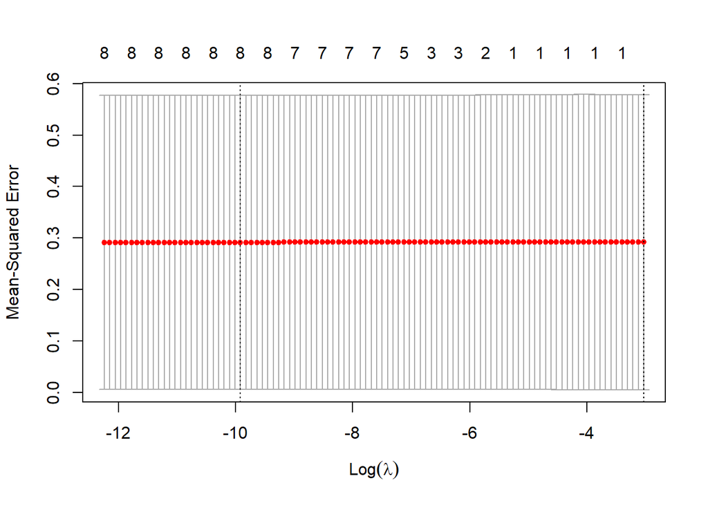

```r
cv_fit5=cv.glmnet(data.matrix(trainingdata5[,-c(1,2,3)]),trainingdata5$Production,family="gaussian")
plot(cv_fit5)
```

```r
coef(cv_fit5,s='lambda.1se')
```

```
## 13 x 1 sparse Matrix of class "dgCMatrix"
##                                      1
## (Intercept)                 0.04195704
## CLOUD_LOW_LAYER_37.75_34.25 .
## CLOUD_LOW_LAYER_37.75_34.5  .
## CLOUD_LOW_LAYER_38_34.25    .
## CLOUD_LOW_LAYER_38_34.5     .
## DSWRF_37.75_34.25           .
## DSWRF_37.75_34.5            .
## DSWRF_38_34.25              .
## DSWRF_38_34.5               .
## TEMP_37.75_34.25            .
## TEMP_37.75_34.5             .
## TEMP_38_34.25               .
## TEMP_38_34.5                .
```

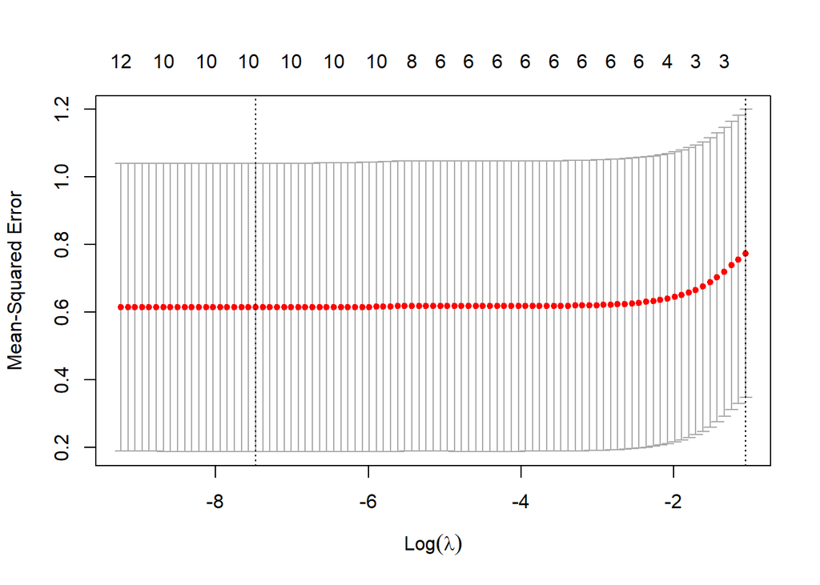

```r
predicted_lasso_model5=predict(cv_fit5,data.matrix(trainingdata5[,-c(1,2,3)]),s='lambda.min')
lasso5_MSE=mean((trainingdata5$Production-predicted_lasso_model5)^2)
predicted_lasso_model5_test=predict(cv_fit5,data.matrix(testdata5[,-c(1,2,3)]),s='lambda.min')
lasso5_test_MSE=mean((testdata5$Production-predicted_lasso_model5_test)^2)

cv_fit6=cv.glmnet(data.matrix(trainingdata6[,-c(1,2,3)]),trainingdata6$Production,family="gaussian")
plot(cv_fit6)
```

```r
coef(cv_fit6,s='lambda.1se')
```

```
## 13 x 1 sparse Matrix of class "dgCMatrix"
##                                     1
## (Intercept)                 0.4142243
## CLOUD_LOW_LAYER_37.75_34.25 .
## CLOUD_LOW_LAYER_37.75_34.5  .
## CLOUD_LOW_LAYER_38_34.25    .
## CLOUD_LOW_LAYER_38_34.5     .
## DSWRF_37.75_34.25           .
## DSWRF_37.75_34.5            .
## DSWRF_38_34.25              .
## DSWRF_38_34.5               .
## TEMP_37.75_34.25            .
## TEMP_37.75_34.5             .
## TEMP_38_34.25               .
## TEMP_38_34.5                .
```

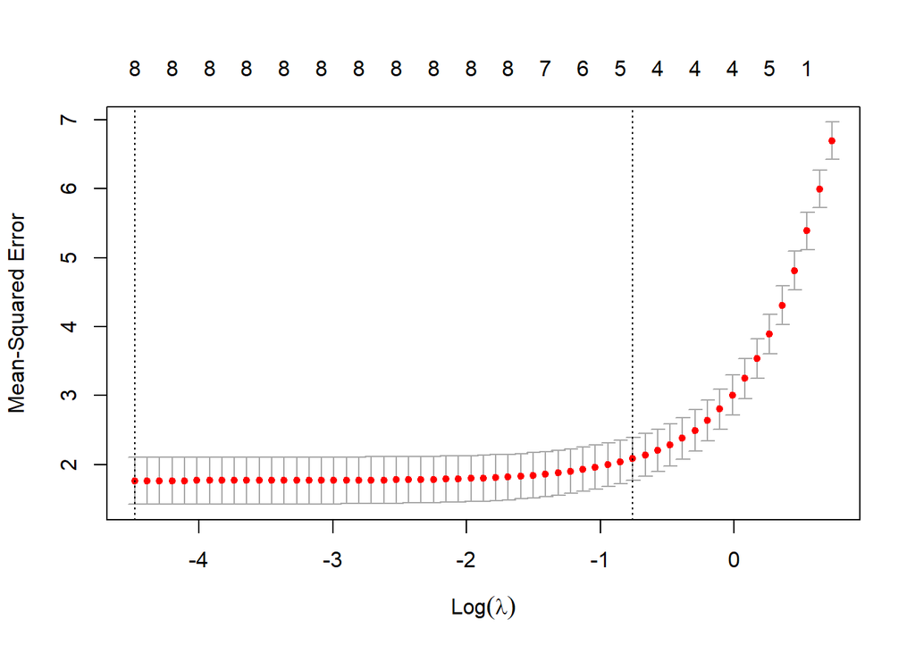

```r
predicted_lasso_model6=predict(cv_fit6,data.matrix(trainingdata6[,-c(1,2,3)]),s='lambda.min')
lasso6_MSE=mean((trainingdata6$Production-predicted_lasso_model6)^2)
predicted_lasso_model6_test=predict(cv_fit6,data.matrix(testdata6[,-c(1,2,3)]),s='lambda.min')
lasso6_test_MSE=mean((testdata6$Production-predicted_lasso_model6_test)^2)

cv_fit7=cv.glmnet(data.matrix(trainingdata7[,-c(1,2,3)]),trainingdata7$Production,family="gaussian")
plot(cv_fit7)
```

```r
coef(cv_fit7,s='lambda.1se')
```

```
## 13 x 1 sparse Matrix of class "dgCMatrix"
##                                       1
## (Intercept)                 1.081339674
## CLOUD_LOW_LAYER_37.75_34.25 .
## CLOUD_LOW_LAYER_37.75_34.5  .
## CLOUD_LOW_LAYER_38_34.25    .
## CLOUD_LOW_LAYER_38_34.5     .
## DSWRF_37.75_34.25           0.053008145
## DSWRF_37.75_34.5            .
## DSWRF_38_34.25              .
## DSWRF_38_34.5               0.028409579
## TEMP_37.75_34.25            0.047328676
## TEMP_37.75_34.5             .
## TEMP_38_34.25               0.047309205
## TEMP_38_34.5                0.004113713
```

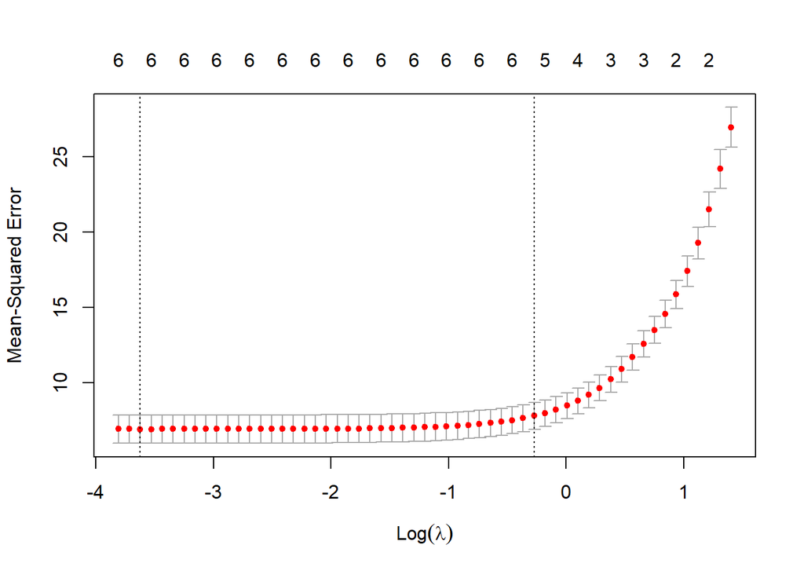

```r
predicted_lasso_model7=predict(cv_fit7,data.matrix(trainingdata7[,-c(1,2,3)]),s='lambda.min')
lasso7_MSE=mean((trainingdata7$Production-predicted_lasso_model7)^2)
predicted_lasso_model7_test=predict(cv_fit7,data.matrix(testdata7[,-c(1,2,3)]),s='lambda.min')
lasso7_test_MSE=mean((testdata7$Production-predicted_lasso_model7_test)^2)

cv_fit8=cv.glmnet(data.matrix(trainingdata8[,-c(1,2,3)]),trainingdata8$Production,family="gaussian")
plot(cv_fit8)
```

```r
coef(cv_fit8,s='lambda.1se')
```

```
## 13 x 1 sparse Matrix of class "dgCMatrix"
##                                         1
## (Intercept)                  4.896056e+00
## CLOUD_LOW_LAYER_37.75_34.25 -5.022600e-03
## CLOUD_LOW_LAYER_37.75_34.5   .
## CLOUD_LOW_LAYER_38_34.25    -2.347720e-02
## CLOUD_LOW_LAYER_38_34.5      .
## DSWRF_37.75_34.25            5.286878e-03
## DSWRF_37.75_34.5             .
## DSWRF_38_34.25               .
## DSWRF_38_34.5                4.757512e-02
## TEMP_37.75_34.25             1.718233e-01
## TEMP_37.75_34.5              1.380707e-05
## TEMP_38_34.25                .
## TEMP_38_34.5                 .
```

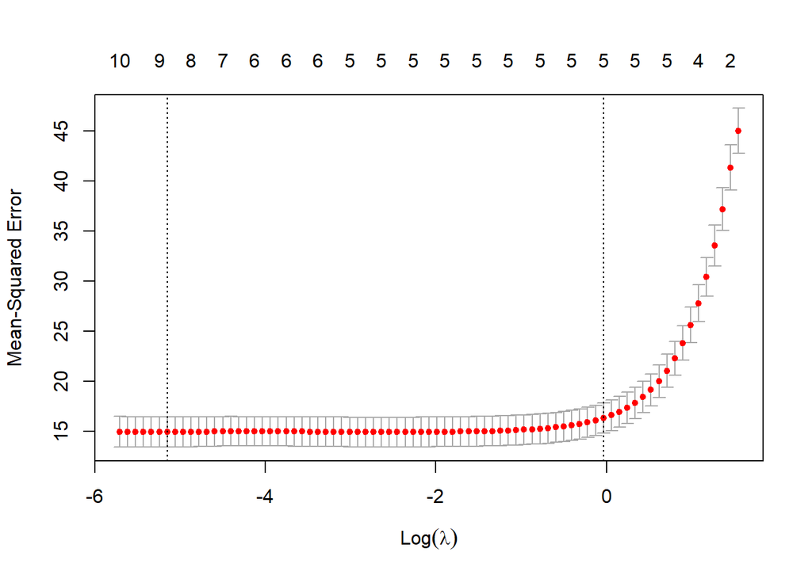

```r
predicted_lasso_model8=predict(cv_fit8,data.matrix(trainingdata8[,-c(1,2,3)]),s='lambda.min')
lasso8_MSE=mean((trainingdata8$Production-predicted_lasso_model8)^2)
predicted_lasso_model8_test=predict(cv_fit8,data.matrix(testdata8[,-c(1,2,3)]),s='lambda.min')
lasso8_test_MSE=mean((testdata8$Production-predicted_lasso_model8_test)^2)

cv_fit9=cv.glmnet(data.matrix(trainingdata9[,-c(1,2,3)]),trainingdata9$Production,family="gaussian")
plot(cv_fit9)
```

```r
coef(cv_fit9,s='lambda.1se')
```

```
## 13 x 1 sparse Matrix of class "dgCMatrix"
##                                       1
## (Intercept)                 11.45349197
## CLOUD_LOW_LAYER_37.75_34.25 -0.02500890
## CLOUD_LOW_LAYER_37.75_34.5   .
## CLOUD_LOW_LAYER_38_34.25    -0.05311161
## CLOUD_LOW_LAYER_38_34.5      .
## DSWRF_37.75_34.25            0.01158872
## DSWRF_37.75_34.5             0.02443142
## DSWRF_38_34.25               .
## DSWRF_38_34.5                .
## TEMP_37.75_34.25             .
## TEMP_37.75_34.5              0.10263492
## TEMP_38_34.25                .
## TEMP_38_34.5                 .
```

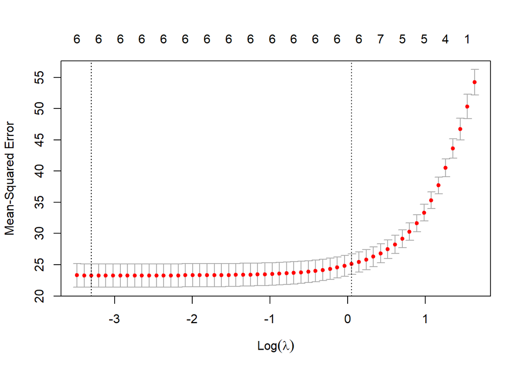

```r
predicted_lasso_model9=predict(cv_fit9,data.matrix(trainingdata9[,-c(1,2,3)]),s='lambda.min')
lasso9_MSE=mean((trainingdata9$Production-predicted_lasso_model9)^2)
predicted_lasso_model9_test=predict(cv_fit9,data.matrix(testdata9[,-c(1,2,3)]),s='lambda.min')
lasso9_test_MSE=mean((testdata9$Production-predicted_lasso_model9_test)^2)

cv_fit10=cv.glmnet(data.matrix(trainingdata10[,-c(1,2,3)]),trainingdata10$Production,family="gaussian")
plot(cv_fit10)
```

```r
coef(cv_fit10,s='lambda.1se')
```

```
## 13 x 1 sparse Matrix of class "dgCMatrix"
##                                        1
## (Intercept)                 13.195701539
## CLOUD_LOW_LAYER_37.75_34.25  .
## CLOUD_LOW_LAYER_37.75_34.5  -0.026789537
## CLOUD_LOW_LAYER_38_34.25    -0.031144715
## CLOUD_LOW_LAYER_38_34.5     -0.013052143
## DSWRF_37.75_34.25            0.005652321
## DSWRF_37.75_34.5             0.008350586
## DSWRF_38_34.25               .
## DSWRF_38_34.5                .
## TEMP_37.75_34.25             .
## TEMP_37.75_34.5              0.017714075
## TEMP_38_34.25                .
## TEMP_38_34.5                 .
```

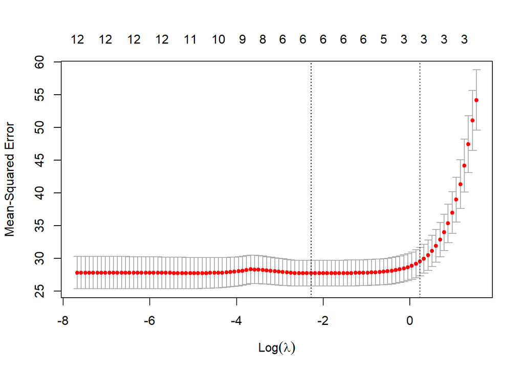

```r
predicted_lasso_model10=predict(cv_fit10,data.matrix(trainingdata10[,-c(1,2,3)]),s='lambda.min')
lasso10_MSE=mean((trainingdata10$Production-predicted_lasso_model10)^2)
predicted_lasso_model10_test=predict(cv_fit10,data.matrix(testdata10[,-c(1,2,3)]),s='lambda.min')
lasso10_test_MSE=mean((testdata10$Production-predicted_lasso_model10_test)^2)

cv_fit11=cv.glmnet(data.matrix(trainingdata11[,-c(1,2,3)]),trainingdata11$Production,family="gaussian")
plot(cv_fit11)
```

```r
coef(cv_fit11,s='lambda.1se')
```

```
## 13 x 1 sparse Matrix of class "dgCMatrix"
##                                        1
## (Intercept)                 17.309320417
## CLOUD_LOW_LAYER_37.75_34.25 -0.034974175
## CLOUD_LOW_LAYER_37.75_34.5   .
## CLOUD_LOW_LAYER_38_34.25    -0.052765149
## CLOUD_LOW_LAYER_38_34.5      .
## DSWRF_37.75_34.25            .
## DSWRF_37.75_34.5             0.008506969
## DSWRF_38_34.25               .
## DSWRF_38_34.5                .
## TEMP_37.75_34.25             .
## TEMP_37.75_34.5              .
## TEMP_38_34.25                .
## TEMP_38_34.5                 .
```

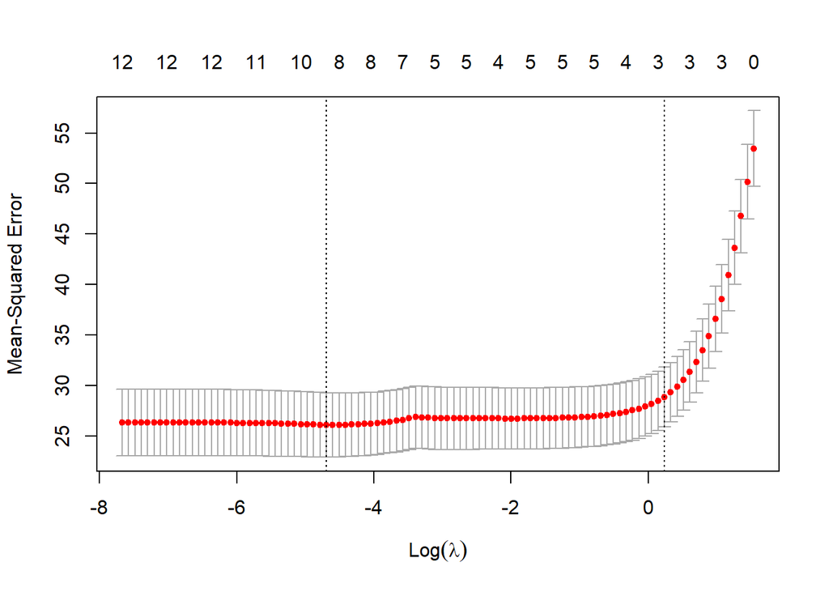

```r
predicted_lasso_model11=predict(cv_fit11,data.matrix(trainingdata11[,-c(1,2,3)]),s='lambda.min')
lasso11_MSE=mean((trainingdata11$Production-predicted_lasso_model11)^2)
predicted_lasso_model11_test=predict(cv_fit11,data.matrix(testdata11[,-c(1,2,3)]),s='lambda.min')
lasso11_test_MSE=mean((testdata11$Production-predicted_lasso_model11_test)^2)

cv_fit12=cv.glmnet(data.matrix(trainingdata12[,-c(1,2,3)]),trainingdata12$Production,family="gaussian")
plot(cv_fit12)
```

```r
coef(cv_fit12,s='lambda.1se')
```

```
## 13 x 1 sparse Matrix of class "dgCMatrix"
##                                        1
## (Intercept)                 16.957965734
## CLOUD_LOW_LAYER_37.75_34.25 -0.040281086
## CLOUD_LOW_LAYER_37.75_34.5   .
## CLOUD_LOW_LAYER_38_34.25    -0.049882482
## CLOUD_LOW_LAYER_38_34.5      .
## DSWRF_37.75_34.25            .
## DSWRF_37.75_34.5             0.008156206
## DSWRF_38_34.25               .
## DSWRF_38_34.5                .
## TEMP_37.75_34.25             .
## TEMP_37.75_34.5              .
## TEMP_38_34.25                .
## TEMP_38_34.5                 .
```

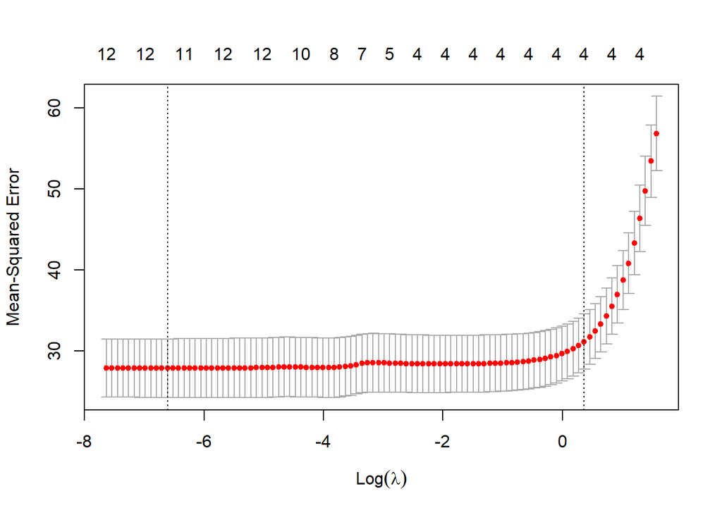

```r
predicted_lasso_model12=predict(cv_fit12,data.matrix(trainingdata12[,-c(1,2,3)]),s='lambda.min')
lasso12_MSE=mean((trainingdata12$Production-predicted_lasso_model12)^2)
predicted_lasso_model12_test=predict(cv_fit12,data.matrix(testdata12[,-c(1,2,3)]),s='lambda.min')
lasso12_test_MSE=mean((testdata12$Production-predicted_lasso_model12_test)^2)

cv_fit13=cv.glmnet(data.matrix(trainingdata13[,-c(1,2,3)]),trainingdata13$Production,family="gaussian")
plot(cv_fit13)
```

```r
coef(cv_fit13,s='lambda.1se')
```

```
## 13 x 1 sparse Matrix of class "dgCMatrix"
##                                        1
## (Intercept)                 16.289448490
## CLOUD_LOW_LAYER_37.75_34.25  .
## CLOUD_LOW_LAYER_37.75_34.5  -0.034353338
## CLOUD_LOW_LAYER_38_34.25    -0.054942691
## CLOUD_LOW_LAYER_38_34.5      .
## DSWRF_37.75_34.25            .
## DSWRF_37.75_34.5             0.005810104
## DSWRF_38_34.25               .
## DSWRF_38_34.5                0.001803943
## TEMP_37.75_34.25             .
## TEMP_37.75_34.5              .
## TEMP_38_34.25                .
## TEMP_38_34.5                 .
```

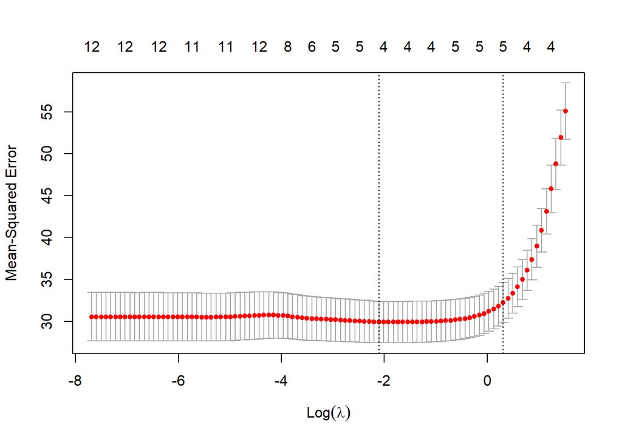

```r
predicted_lasso_model13=predict(cv_fit13,data.matrix(trainingdata13[,-c(1,2,3)]),s='lambda.min')
lasso13_MSE=mean((trainingdata13$Production-predicted_lasso_model13)^2)
predicted_lasso_model13_test=predict(cv_fit13,data.matrix(testdata13[,-c(1,2,3)]),s='lambda.min')
lasso13_test_MSE=mean((testdata13$Production-predicted_lasso_model13_test)^2)

cv_fit14=cv.glmnet(data.matrix(trainingdata14[,-c(1,2,3)]),trainingdata14$Production,family="gaussian")
plot(cv_fit14)
```

```r
coef(cv_fit14,s='lambda.1se')
```

```
## 13 x 1 sparse Matrix of class "dgCMatrix"
##                                         1
## (Intercept)                 12.4960401324
## CLOUD_LOW_LAYER_37.75_34.25 -0.0340561962
## CLOUD_LOW_LAYER_37.75_34.5   .
## CLOUD_LOW_LAYER_38_34.25    -0.0271807158
## CLOUD_LOW_LAYER_38_34.5      .
## DSWRF_37.75_34.25            0.0021037051
## DSWRF_37.75_34.5             .
## DSWRF_38_34.25               0.0080414704
## DSWRF_38_34.5                0.0001833331
## TEMP_37.75_34.25             .
## TEMP_37.75_34.5              .
## TEMP_38_34.25                .
## TEMP_38_34.5                 .
```

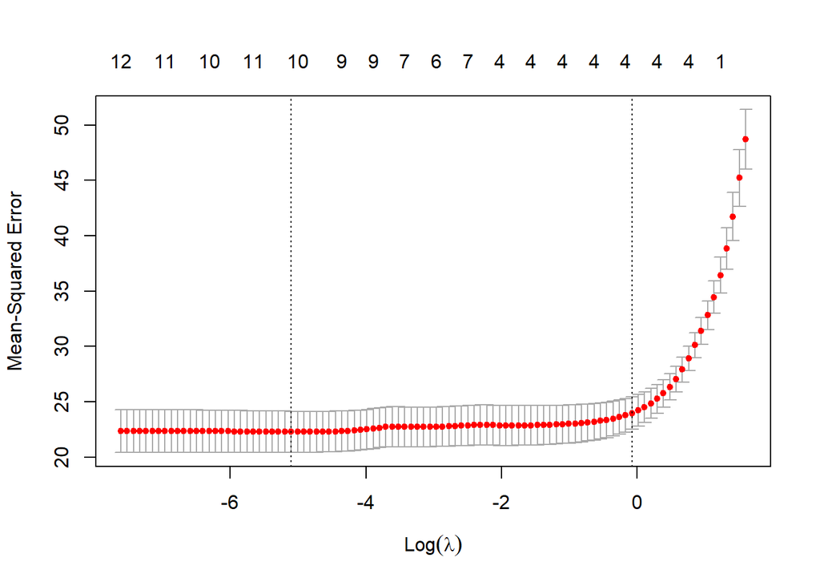

```r
predicted_lasso_model14=predict(cv_fit14,data.matrix(trainingdata14[,-c(1,2,3)]),s='lambda.min')
lasso14_MSE=mean((trainingdata14$Production-predicted_lasso_model14)^2)
predicted_lasso_model14_test=predict(cv_fit14,data.matrix(testdata14[,-c(1,2,3)]),s='lambda.min')
lasso14_test_MSE=mean((testdata14$Production-predicted_lasso_model14_test)^2)

cv_fit15=cv.glmnet(data.matrix(trainingdata15[,-c(1,2,3)]),trainingdata15$Production,family="gaussian")
plot(cv_fit15)
```

```r
coef(cv_fit15,s='lambda.1se')
```

```
## 13 x 1 sparse Matrix of class "dgCMatrix"
##                                        1
## (Intercept)                  5.897881663
## CLOUD_LOW_LAYER_37.75_34.25  .
## CLOUD_LOW_LAYER_37.75_34.5   .
## CLOUD_LOW_LAYER_38_34.25    -0.038983548
## CLOUD_LOW_LAYER_38_34.5      .
## DSWRF_37.75_34.25            0.005560076
## DSWRF_37.75_34.5             .
## DSWRF_38_34.25               0.008439777
## DSWRF_38_34.5                0.001548340
## TEMP_37.75_34.25             .
## TEMP_37.75_34.5              .
## TEMP_38_34.25                .
## TEMP_38_34.5                 .
```

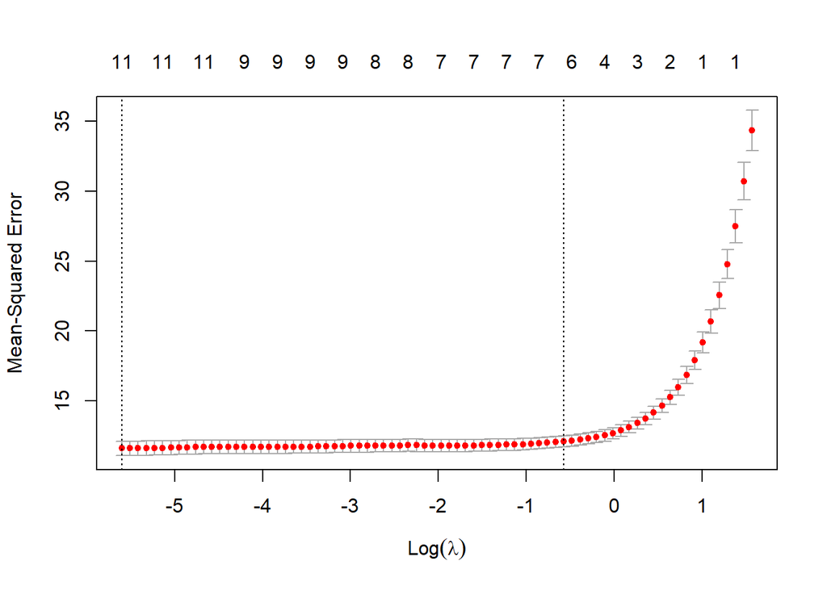

```r
predicted_lasso_model15=predict(cv_fit15,data.matrix(trainingdata15[,-c(1,2,3)]),s='lambda.min')
lasso15_MSE=mean((trainingdata15$Production-predicted_lasso_model15)^2)
predicted_lasso_model15_test=predict(cv_fit15,data.matrix(testdata15[,-c(1,2,3)]),s='lambda.min')
lasso15_test_MSE=mean((testdata15$Production-predicted_lasso_model15_test)^2)

cv_fit16=cv.glmnet(data.matrix(trainingdata16[,-c(1,2,3)]),trainingdata16$Production,family="gaussian")
plot(cv_fit16)
```

```r
coef(cv_fit16,s='lambda.1se')
```

```
## 13 x 1 sparse Matrix of class "dgCMatrix"
##                                         1
## (Intercept)                  0.5677846823
## CLOUD_LOW_LAYER_37.75_34.25 -0.0001422487
## CLOUD_LOW_LAYER_37.75_34.5   .
## CLOUD_LOW_LAYER_38_34.25    -0.0009652147
## CLOUD_LOW_LAYER_38_34.5      .
## DSWRF_37.75_34.25            0.0133742222
## DSWRF_37.75_34.5             0.0002860222
## DSWRF_38_34.25               0.0028513938
## DSWRF_38_34.5                0.0021939297
## TEMP_37.75_34.25             .
## TEMP_37.75_34.5              .
## TEMP_38_34.25                0.0128072435
## TEMP_38_34.5                 .
```

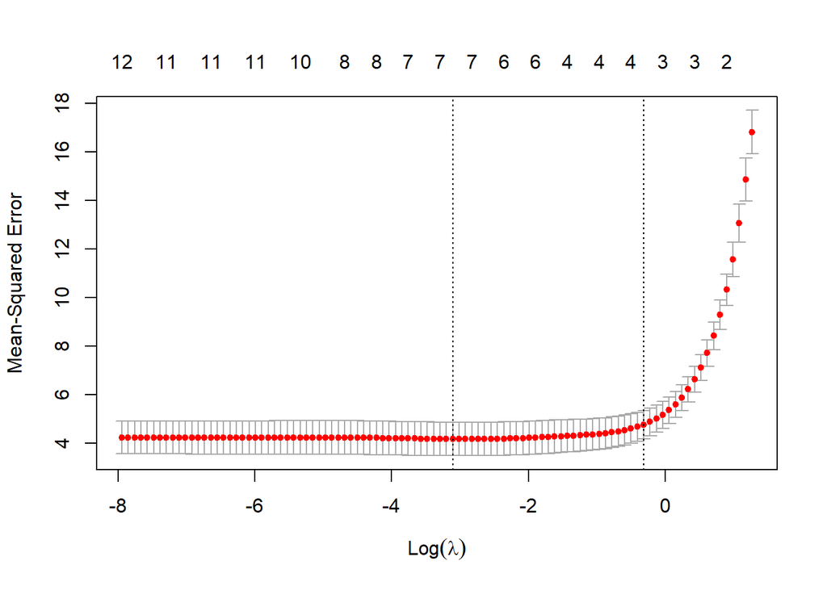

```r
predicted_lasso_model16=predict(cv_fit16,data.matrix(trainingdata16[,-c(1,2,3)]),s='lambda.min')
lasso16_MSE=mean((trainingdata16$Production-predicted_lasso_model16)^2)
predicted_lasso_model16_test=predict(cv_fit16,data.matrix(testdata16[,-c(1,2,3)]),s='lambda.min')
lasso16_test_MSE=mean((testdata16$Production-predicted_lasso_model16_test)^2)

cv_fit17=cv.glmnet(data.matrix(trainingdata17[,-c(1,2,3)]),trainingdata17$Production,family="gaussian")
plot(cv_fit17)
```

```r
coef(cv_fit17,s='lambda.1se')
```

```
## 13 x 1 sparse Matrix of class "dgCMatrix"
##                                         1
## (Intercept)                 -1.1649548531
## CLOUD_LOW_LAYER_37.75_34.25  .
## CLOUD_LOW_LAYER_37.75_34.5   .
## CLOUD_LOW_LAYER_38_34.25     .
## CLOUD_LOW_LAYER_38_34.5      .
## DSWRF_37.75_34.25            0.0065221797
## DSWRF_37.75_34.5             0.0023621446
## DSWRF_38_34.25               0.0046828661
## DSWRF_38_34.5                0.0001186582
## TEMP_37.75_34.25             .
## TEMP_37.75_34.5              .
## TEMP_38_34.25                .
## TEMP_38_34.5                 .
```

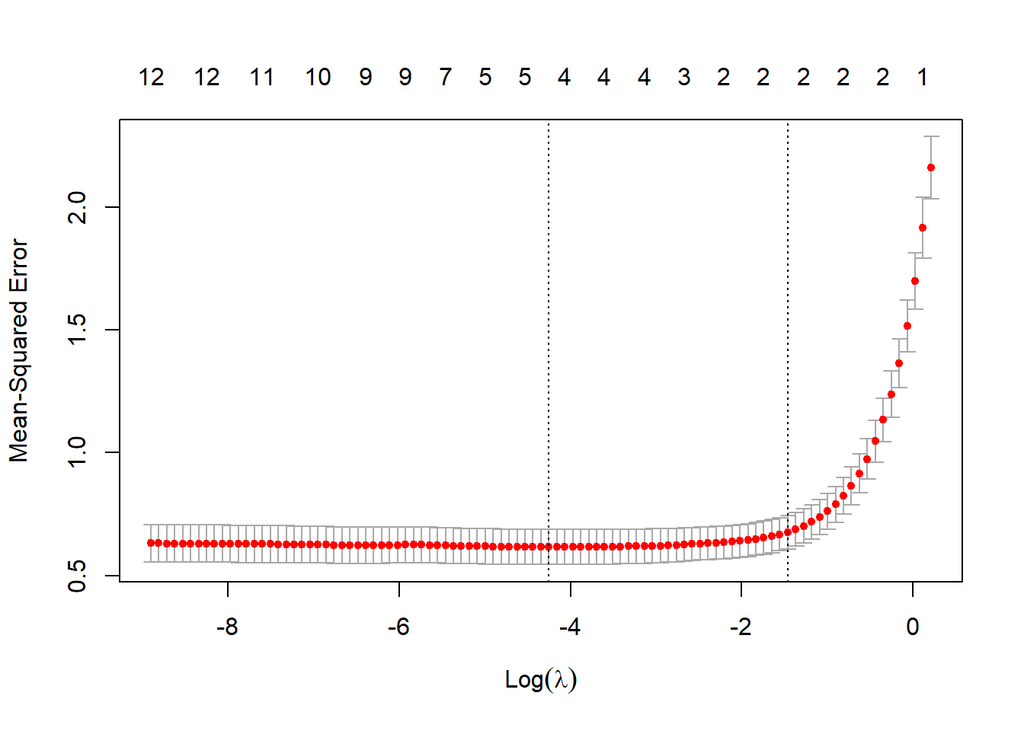

```r
predicted_lasso_model17=predict(cv_fit17,data.matrix(trainingdata17[,-c(1,2,3)]),s='lambda.min')
lasso17_MSE=mean((trainingdata17$Production-predicted_lasso_model17)^2)
predicted_lasso_model17_test=predict(cv_fit17,data.matrix(testdata17[,-c(1,2,3)]),s='lambda.min')
lasso17_test_MSE=mean((testdata17$Production-predicted_lasso_model17_test)^2)

cv_fit18=cv.glmnet(data.matrix(trainingdata18[,-c(1,2,3)]),trainingdata18$Production,family="gaussian")
plot(cv_fit18)
```

```r
coef(cv_fit18,s='lambda.1se')
```

```
## 13 x 1 sparse Matrix of class "dgCMatrix"
##                                        1
## (Intercept)                 -0.663029935
## CLOUD_LOW_LAYER_37.75_34.25  .
## CLOUD_LOW_LAYER_37.75_34.5   .
## CLOUD_LOW_LAYER_38_34.25     .
## CLOUD_LOW_LAYER_38_34.5      .
## DSWRF_37.75_34.25            .
## DSWRF_37.75_34.5             0.002231664
## DSWRF_38_34.25               0.003124654
## DSWRF_38_34.5                .
## TEMP_37.75_34.25             .
## TEMP_37.75_34.5              .
## TEMP_38_34.25                .
## TEMP_38_34.5                 .
```

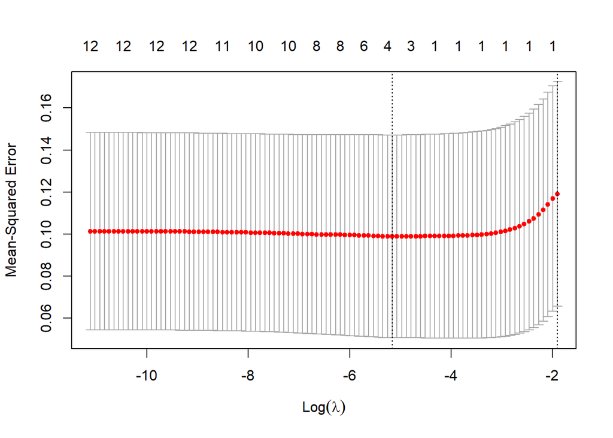

```r
predicted_lasso_model18=predict(cv_fit18,data.matrix(trainingdata18[,-c(1,2,3)]),s='lambda.min')
lasso18_MSE=mean((trainingdata18$Production-predicted_lasso_model18)^2)
predicted_lasso_model18_test=predict(cv_fit18,data.matrix(testdata18[,-c(1,2,3)]),s='lambda.min')
lasso18_test_MSE=mean((testdata18$Production-predicted_lasso_model18_test)^2)

cv_fit19=cv.glmnet(data.matrix(trainingdata19[,-c(1,2,3)]),trainingdata19$Production,family="gaussian")
plot(cv_fit19)
```

```r
coef(cv_fit19,s='lambda.1se')
```

```
## 13 x 1 sparse Matrix of class "dgCMatrix"
##                                     1
## (Intercept)                 0.1082578
## CLOUD_LOW_LAYER_37.75_34.25 .
## CLOUD_LOW_LAYER_37.75_34.5  .
## CLOUD_LOW_LAYER_38_34.25    .
## CLOUD_LOW_LAYER_38_34.5     .
## DSWRF_37.75_34.25           .
## DSWRF_37.75_34.5            .
## DSWRF_38_34.25              .
## DSWRF_38_34.5               .
## TEMP_37.75_34.25            .
## TEMP_37.75_34.5             .
## TEMP_38_34.25               .
## TEMP_38_34.5                .
```

```r
predicted_lasso_model19=predict(cv_fit19,data.matrix(trainingdata19[,-c(1,2,3)]),s='lambda.min')
lasso19_MSE=mean((trainingdata19$Production-predicted_lasso_model19)^2)
predicted_lasso_model19_test=predict(cv_fit19,data.matrix(testdata19[,-c(1,2,3)]),s='lambda.min')
lasso19_test_MSE=mean((testdata19$Production-predicted_lasso_model19_test)^2)
```

At the end, we calculated average Mean Square Error for all lasso regression models.

```r
lasso_Avg_MSE=mean(c(lasso5_MSE,lasso6_MSE,lasso7_MSE,lasso8_MSE,+
                       lasso9_MSE,lasso10_MSE,lasso11_MSE,lasso12_MSE,lasso13_MSE,+
                       lasso14_MSE,lasso15_MSE,lasso16_MSE,lasso17_MSE,lasso18_MSE,lasso19_MSE))
lasso_Avg_MSE
```

```
## [1] 12.45565
```

```r
lasso_Avg_test_MSE=mean(c(lasso5_test_MSE,lasso6_test_MSE,lasso7_test_MSE,lasso8_test_MSE,+
                            lasso9_test_MSE,lasso10_test_MSE,lasso11_test_MSE,lasso12_test_MSE,lasso13_test_MSE,+
                            lasso14_test_MSE,lasso15_test_MSE,lasso16_test_MSE,lasso17_test_MSE,lasso18_test_MSE,lasso19_test_MSE))
lasso_Avg_test_MSE
```

```
## [1] 22.78356
```